# R course

Christophe Pallier pour RITME

6/7/2019

# Le langage R et son ecosystème

Dans les années 1970-80, des chercheurs des Bell labs ont inventé un langage, **S**, pour permettre de faire de statistiques de manière interactive et plus efficace qu’en programmant en FORTRAN.

**R** est une implémentation open-source de **S** développée dans les années 90.

Le site officiel de **R** est https://cran.r-project.org/

En plus du logiciel **R**, on peut trouver sur ce site de nombreuses documentations et des librairies (aka ‘packages’) qui ajoutent des fonctionnalités à R (Explorer les liens `Documentation` `Task View` dans le menu de la page d’acceuil du CRAN).

**Rstudio** est un environnement de développement (IDE) qui facilite l’utilisation de R. Il peut-être téléchargé depuis http://www.rstudio.org

## Courte démo de Rstudio

1. exécuter le code suivant dans la console:

```r
    data("AirPassengers")
    str(AirPassengers)
```

```
##  Time-Series [1:144] from 1949 to 1961: 112 118 132 129 121 135 148 148 136 119 ...
```

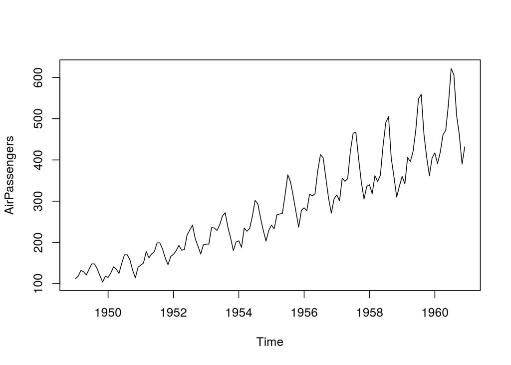

```r
    ?AirPassengers
    plot(AirPassengers)
```

Regarder les onglets `Plots` et `Global Environment`

2. Créer des rapports en utilisant le format Rmarkdown.

Un fichier *Rmarkdown* (extension `Rmd`) contient des blocs de codes R (chunks) et du texte libre. A partir ce ce fichier, on peut générer un document html, pdf, etc… qui contient les texte formaté et le résultat des commandes R.

Exemple:

- Créer un projet avec `File/New Projet`
- cliquer sur `File/New File/Rmarkdown`
- Supprimer de la ligne 8 jusqu’à la fin; puis cliquez sur `Insert/R` (ou `Ctrl-Atl-I`). Cela insère un *chunk* de code.

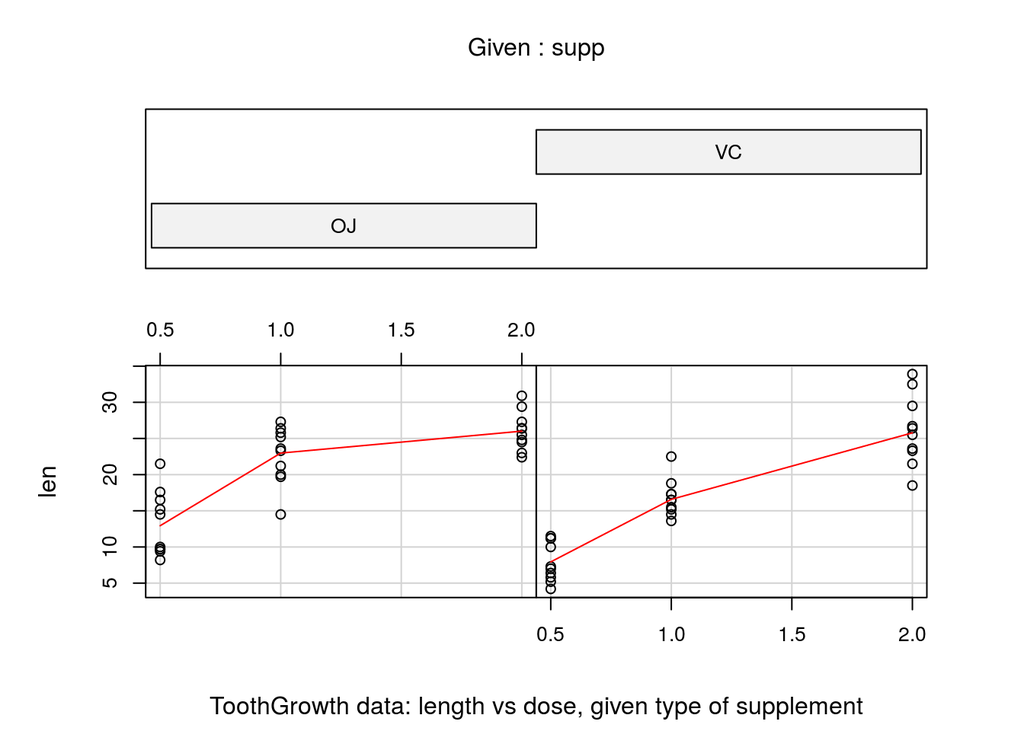

```r
    data("ToothGrowth")
    coplot(len ~ dose | supp, data = ToothGrowth, panel = panel.smooth,
           xlab = "ToothGrowth data: length vs dose, given type of supplement")
```

Exemple de documents rédigé en Rmarkdown:

- http://www.pallier.org/pdfs/methodo-recueil-manipulation.pdf
- Pour plus d’info, consulter:
  - https://blog.wax-o.com/2014/04/tutoriel-un-guide-pour-bien-commencer-avec-markdown/
  - https://kbroman.org/knitr_knutshell/pages/Rmarkdown.html

On trouve sur le site de rstudio de nombreuses antisèches bien utiles: https://www.rstudio.com/resources/cheatsheets/

## Fondamentaux du langage

### Exécution de code

En mode interactif (à la console): on entre une expression (ou une commande) qui est immédiatement évaluée (ou exécutée) dès qu’on appuie sur la touche ‘Entrée’.

```
 2 * pi  # expression
 plot(sin(seq(-6,6,.1)))  # commande
```

On peut également exécuter du code R sauvé dans un fichier texte (extension `.R`) avec la commande `source('code.R', echo=TRUE)`. Remarque: on peut même exécuter un code qui se trouve sur Internet en passant une URL comme argument.

Ou bien directement dans un Terminal avec `Rscript code.R`.

Pour compiler un document rmarkdown directement depuis le terminal (sans ouvrir rstudio): `R -e "rmarkdown::render('doc.Rmd')"`

### Objets de base de R

#### Vecteurs

Dans R, à l’instar de MATLAB, il n’y pas de distinction entre scalaire (nombre unique) et vecteur (le vecteur est un object de base, “atomic” de R)

Les éléments d’un vecteur doivent tous être du même type (numeric, character, logical, …); Attention: R peut faire des conversions automatiques pour respecter cette règle.

```r
  1
```

```
## [1] 1
```

```r
  1 + 3i
```

```
## [1] 1+3i
```

```r
  c(1, 3, 4, 2)
```

```
## [1] 1 3 4 2
```

```r
  c('alpha', 'beta', 'gamma')
```

```
## [1] "alpha" "beta"  "gamma"
```

```r
  c(TRUE, FALSE, FALSE)
```

```
## [1]  TRUE FALSE FALSE
```

```r
  c(TRUE, 'FALSE')
```

```
## [1] "TRUE"  "FALSE"
```

```r
  c(1, "3")
```

```
## [1] "1" "3"
```

```r
   1 + 1
```

```
## [1] 2
```

```r
   1 + NaN
```

```
## [1] NaN
```

```r
   1 + Inf
```

```
## [1] Inf
```

```r
   Inf / Inf
```

```
## [1] NaN
```

```r
   1:10
```

```
##  [1]  1  2  3  4  5  6  7  8  9 10
```

```r
   1:10 + 5
```

```
##  [1]  6  7  8  9 10 11 12 13 14 15
```

```r
   5 * (1:10)
```

```
##  [1]  5 10 15 20 25 30 35 40 45 50
```

```r
   1:10 + 100:109
```

```
##  [1] 101 103 105 107 109 111 113 115 117 119
```

```r
   1:10 + 1:2
```

```
##  [1]  2  4  4  6  6  8  8 10 10 12
```

Création de vecteurs:

```r
numeric(100)
```

```
##   [1] 0 0 0 0 0 0 0 0 0 0 0 0 0 0 0 0 0 0 0 0 0 0 0 0 0 0 0 0 0 0 0 0 0 0 0
##  [36] 0 0 0 0 0 0 0 0 0 0 0 0 0 0 0 0 0 0 0 0 0 0 0 0 0 0 0 0 0 0 0 0 0 0 0
##  [71] 0 0 0 0 0 0 0 0 0 0 0 0 0 0 0 0 0 0 0 0 0 0 0 0 0 0 0 0 0 0
```

```r
c(.3, .45, .1)
```

```
## [1] 0.30 0.45 0.10
```

```r
c('alpha', 'beta', 'gamma')
```

```
## [1] "alpha" "beta"  "gamma"
```

On peut lire un vecteur à partir d’un fichier texte avec la fonction `scan`:

```r
write(rnorm(10), file='valeurs.dat')
a = scan('valeurs.dat')
print(a)
```

```
##  [1] -1.3396820  0.8409911 -1.5436640 -0.5745374 -0.3548932 -1.1817750
##  [7] -1.2101240 -0.4236886 -0.9037681  2.3047380
```

```r
b = scan('rcourse.Rmd', what=character())
b[1:10]
```

```
##  [1] "---"                           "title:"
##  [3] "R course"                      "author:"
##  [5] "Christophe Pallier pour RITME" "date:"
##  [7] "6/7/2019"                      "output:"
##  [9] "html_document:"                "toc:"
```

Les fonctions `seq`, `rep` et `replicate` sont souvent utiles pour générer des vecteurs:

```r
seq(0, 1, .1)
```

```
##  [1] 0.0 0.1 0.2 0.3 0.4 0.5 0.6 0.7 0.8 0.9 1.0
```

```r
rep(3.14, 5)
```

```
## [1] 3.14 3.14 3.14 3.14 3.14
```

```r
rep(c(1, 2), 3)
```

```
## [1] 1 2 1 2 1 2
```

```r
rep(c(1, 2), c(5, 5))
```

```
##  [1] 1 1 1 1 1 2 2 2 2 2
```

```r
rep(c(1, 2), c(5, 3))
```

```
## [1] 1 1 1 1 1 2 2 2
```

Génération de vecteurs aléatoires:

```r
runif(10, min=1, max=2)  # distribution uniforme
```

```
##  [1] 1.584190 1.820061 1.657803 1.897279 1.405374 1.754481 1.519829
##  [8] 1.389614 1.910188 1.465491
```

```r
rnorm(10, mean=100, sd=10)  # distribution normale
```

```
##  [1] 105.91740  99.66676  99.71575  85.65164 103.88147  99.70796 100.58379
##  [8]  98.40213  96.65214  93.49467
```

```r
?distributions  # autres distributions

require(mvtnorm)  # distribtion multivariée
```

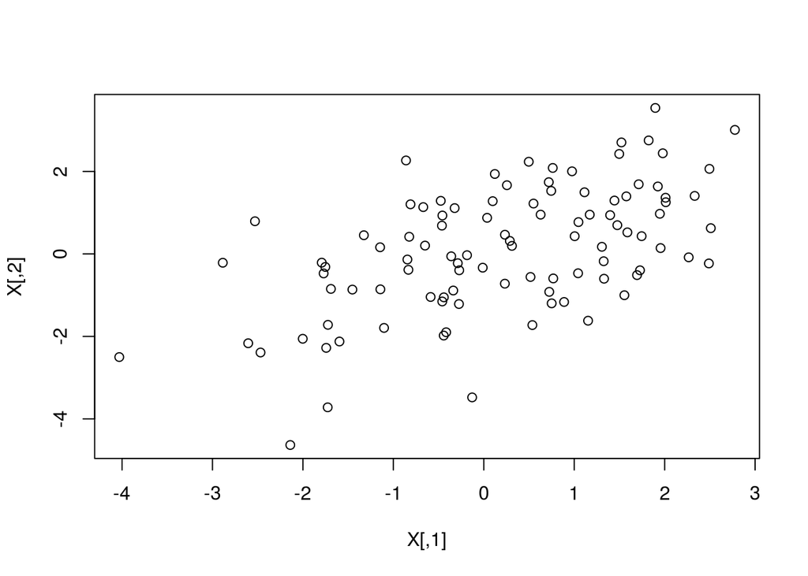

```r
X = rmvnorm(100, sigma=matrix(c(2,1,1,2), 2, 2))
plot(X)
```

```r
sample(c('pile', 'face', 'tranche'), 1000, replace=T, prob=c(.49, .49, 0.02))
```

```
##    [1] "face"    "tranche" "pile"    "pile"    "face"    "face"
##    [7] "face"    "tranche" "pile"    "pile"    "face"    "pile"
##   [13] "pile"    "face"    "face"    "pile"    "face"    "face"
##   [19] "face"    "face"    "face"    "face"    "pile"    "face"
##   [25] "pile"    "face"    "face"    "pile"    "pile"    "face"
##   [31] "face"    "face"    "pile"    "face"    "face"    "pile"
##   [37] "face"    "face"    "pile"    "pile"    "face"    "face"
##   [43] "pile"    "pile"    "pile"    "pile"    "pile"    "face"
##   [49] "face"    "pile"    "face"    "pile"    "pile"    "face"
##   [55] "pile"    "pile"    "pile"    "face"    "face"    "pile"
##   [61] "pile"    "pile"    "pile"    "pile"    "face"    "pile"
##   [67] "face"    "pile"    "pile"    "pile"    "pile"    "face"
##   [73] "face"    "face"    "face"    "face"    "pile"    "pile"
##   [79] "face"    "pile"    "pile"    "face"    "face"    "tranche"
##   [85] "tranche" "pile"    "pile"    "face"    "pile"    "pile"
```

[output cut: 152 more lines]

`replicate(n, expr)` évalue `n` fois l’expression `expr` et renvoit les valeurs obtenues dans un vecteur:

```r
replicate(100, rnorm(1))  # mais on peut faire plus simple: rnorm(100)
```

```
##   [1] -0.717005960 -1.182656502  0.601951540 -2.017594453  0.472203850
##   [6]  1.957657901  1.467174448  0.820063537 -0.365995591  0.292695960
##  [11]  1.355464001 -0.578613266 -1.079119000 -1.160910594 -1.033625958
##  [16] -0.185213893 -0.202112417 -0.202580302  0.979693674 -1.620347838
##  [21]  0.628331053 -0.362867212 -0.949354862  0.684039896  1.100563869
##  [26] -0.262358940 -0.447694163  0.371055876 -0.659100335 -0.384720819
##  [31] -1.522535465 -0.056911648 -0.631122640 -0.118168687  1.760576631
##  [36]  0.909402200 -1.057375989  1.358132602 -1.764921535 -0.551188158
##  [41]  0.404887790 -1.386790497 -0.493623486 -0.683067482 -0.033748170
##  [46] -0.962209654  1.919100737 -0.413537972  0.015252136  0.068137351
##  [51]  1.545600859 -0.130762361  0.334213866  0.295585227  0.197487698
##  [56]  0.559698157 -0.826610168  0.967490611 -1.162865254  2.295914386
##  [61] -1.082466288  2.278908876  0.620732468 -0.691015058 -0.300321610
##  [66]  1.136047398 -0.005870544  0.499157551 -1.738759022  1.797740388
##  [71]  0.445470112  1.166960948  1.709566698  0.042558821  0.270269571
##  [76] -0.527275854  0.462702732 -0.133602095 -0.319624639  0.350381526
##  [81]  0.390526755 -0.514008557 -1.478695065  1.321052058  0.914000083
##  [86] -0.216689881  1.832007521 -0.693198580  1.819398577 -0.188321592
##  [91] -0.115282319 -0.307360279  0.345786273 -1.061212110  0.316230379
##  [96]  1.008765806 -1.939587170  0.085465226 -0.341258118  1.937024936
```

```r
replicate(100, mean(sample(c(0, 0, 1), 10, replace=T)))
```

```
##   [1] 0.5 0.2 0.1 0.2 0.5 0.3 0.3 0.6 0.2 0.4 0.2 0.2 0.3 0.2 0.3 0.6 0.4
##  [18] 0.6 0.0 0.3 0.6 0.4 0.5 0.2 0.3 0.4 0.5 0.4 0.0 0.3 0.2 0.1 0.3 0.1
##  [35] 0.4 0.4 0.3 0.6 0.4 0.3 0.5 0.7 0.3 0.3 0.4 0.3 0.6 0.2 0.3 0.4 0.2
##  [52] 0.4 0.4 0.3 0.3 0.5 0.4 0.2 0.3 0.5 0.4 0.4 0.5 0.5 0.2 0.3 0.2 0.2
##  [69] 0.5 0.3 0.3 0.6 0.2 0.3 0.5 0.4 0.6 0.1 0.4 0.5 0.4 0.3 0.2 0.2 0.2
##  [86] 0.3 0.3 0.5 0.5 0.3 0.4 0.2 0.2 0.3 0.7 0.2 0.4 0.4 0.5 0.2
```

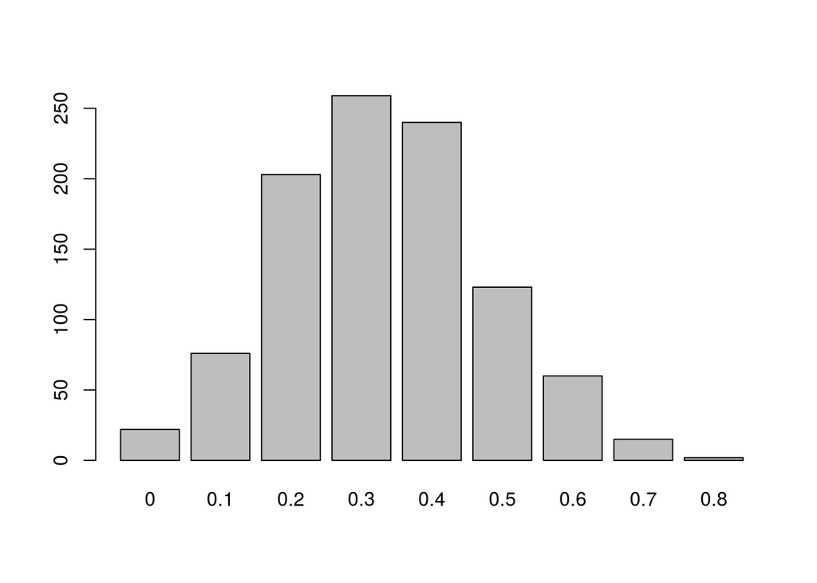

```r
barplot(table(replicate(1000, mean(sample(c(0, 0, 1), 10, replace=T)))))
```

**Exercices**:

- créer le vecteur 1 2 2 3 3 3 4 4 4 4 5 5 5 5 5 … 100

#### noms

On peut attribuer des *noms* aux éléments d’un vecteur, qui peuvent servir ensuite à accéder à ces éléments.

```r
c(a=1, b=2)
```

```
## a b
## 1 2
```

```r
    c(nom='dupont', age=34)
```

```
##      nom      age
## "dupont"     "34"
```

```r
    a = c(nom='dupont', age=34)
    a['nom']
```

```
##      nom
## "dupont"
```

Pour obtenir la liste des noms d’un vecteur, on utilise la fonction `names`:

```r
tirages = sample(c('pile', 'face'), 10, replace=T)
resultats = table(tirages)
resultats
```

```
## tirages
## face pile
##    5    5
```

```r
names(resultats)
```

```
## [1] "face" "pile"
```

Note: le même nom peut-être ré-utilisé (mais ce n’est pas forcément une bonne idée!)

```r
b = c(a=1, a=2, b=3)
print(b)
```

```
## a a b
## 1 2 3
```

```r
names(b)
```

```
## [1] "a" "a" "b"
```

```r
b['a']
```

```
## a
## 1
```

```r
b[names(b)=='a']
```

```
## a a
## 1 2
```

### accès aux éléments d’un vecteur

Il y a trois manières d’accéder aux éléments d’un vecteur:

- par indice numérique de position
- par noms
- par filtre logique

Accès par indice:

```r
 a = rnorm(100)
 a
```

```
##   [1] -1.608402598 -0.234271920 -0.474941947 -1.648772161  0.038941006
##   [6] -0.081995103 -0.066835102  1.606153807 -1.983173175  0.430477038
##  [11]  2.160326815 -0.197489772 -0.581383278 -0.464015103  0.411248179
##  [16]  0.757976457 -0.018178658  0.389176509  0.585151788 -0.142347931
##  [21] -0.624827427 -1.629760488  0.008671756 -0.285713597 -1.206470146
##  [26]  0.340814264  0.761713221  0.609023435 -0.701336230 -1.723237775
##  [31]  1.056611692  0.111424313 -0.769996956  0.470575846  1.439192857
##  [36]  1.273710166  0.336988684 -0.330841852 -0.483203698  0.863767473
##  [41]  1.670695851  1.036169321 -0.036663220  0.082135993  0.197617125
##  [46] -0.913221075 -0.950211609  2.017406479 -1.344709823 -0.384267634
##  [51] -0.946211885 -0.564629909  1.434229247 -0.641377093  1.495483538
##  [56] -0.515080979  1.895683564  1.143274780 -1.662235985  1.695900915
##  [61]  0.203640885  0.381697043 -0.493769417 -0.505087442  0.817309316
##  [66]  0.402327991  1.359847135 -0.563815875 -0.339788757 -0.849045075
##  [71]  1.045379580 -1.348774372 -0.149241212  0.749065177 -0.239456676
##  [76]  1.339023846 -0.740282561 -2.325323984  0.454004579 -1.543338351
##  [81]  0.538039591  1.477287209 -0.944240914 -0.182392163 -0.923569047
##  [86]  0.045694038  1.613323795 -0.441086785 -1.139914620 -0.774469092
##  [91]  0.649105125  0.967703627 -1.787617889 -1.209921604  0.555909974
##  [96] -0.927415671  1.131598455 -0.044001722 -0.862256626  0.510616817
```

```r
 a[10]  # 10e element
```

```
## [1] 0.430477
```

```r
 a[10:19]
```

```
##  [1]  0.43047704  2.16032682 -0.19748977 -0.58138328 -0.46401510
##  [6]  0.41124818  0.75797646 -0.01817866  0.38917651  0.58515179
```

```r
 a[-(1:10)]  # supprime les 10iers éléments
```

```
##  [1]  2.160326815 -0.197489772 -0.581383278 -0.464015103  0.411248179
##  [6]  0.757976457 -0.018178658  0.389176509  0.585151788 -0.142347931
## [11] -0.624827427 -1.629760488  0.008671756 -0.285713597 -1.206470146
## [16]  0.340814264  0.761713221  0.609023435 -0.701336230 -1.723237775
## [21]  1.056611692  0.111424313 -0.769996956  0.470575846  1.439192857
## [26]  1.273710166  0.336988684 -0.330841852 -0.483203698  0.863767473
## [31]  1.670695851  1.036169321 -0.036663220  0.082135993  0.197617125
## [36] -0.913221075 -0.950211609  2.017406479 -1.344709823 -0.384267634
## [41] -0.946211885 -0.564629909  1.434229247 -0.641377093  1.495483538
## [46] -0.515080979  1.895683564  1.143274780 -1.662235985  1.695900915
## [51]  0.203640885  0.381697043 -0.493769417 -0.505087442  0.817309316
## [56]  0.402327991  1.359847135 -0.563815875 -0.339788757 -0.849045075
## [61]  1.045379580 -1.348774372 -0.149241212  0.749065177 -0.239456676
## [66]  1.339023846 -0.740282561 -2.325323984  0.454004579 -1.543338351
## [71]  0.538039591  1.477287209 -0.944240914 -0.182392163 -0.923569047
## [76]  0.045694038  1.613323795 -0.441086785 -1.139914620 -0.774469092
## [81]  0.649105125  0.967703627 -1.787617889 -1.209921604  0.555909974
## [86] -0.927415671  1.131598455 -0.044001722 -0.862256626  0.510616817
```

Accès par nom:

```r
a = table(tirages)
a['pile']
```

```
## pile
##    5
```

Accès par filtrage:

```r
  x = rnorm(20)
  x
```

```
##  [1] -0.21716684  0.88058789 -0.16704486  0.42052741 -0.27860101
##  [6] -0.26565716  1.50960209 -0.71743536 -0.46021755  1.83422817
## [11] -0.18881952 -1.15685643  0.40592322 -0.90464925 -1.35717052
## [16] -0.06880320  1.71852722 -0.07422252 -0.90387005 -0.58198924
```

```r
  x > 0
```

```
##  [1] FALSE  TRUE FALSE  TRUE FALSE FALSE  TRUE FALSE FALSE  TRUE FALSE
## [12] FALSE  TRUE FALSE FALSE FALSE  TRUE FALSE FALSE FALSE
```

```r
  x[x>0]
```

```
## [1] 0.8805879 0.4205274 1.5096021 1.8342282 0.4059232 1.7185272
```

Quelques fonctions utiles: `length`, `sum`, `mean`, `summary`, `unique`, `table`, `sapply`…

```r
x = rnorm(10)
length(x)
```

```
## [1] 10
```

```r
sum(x)
```

```
## [1] -3.263133
```

```r
mean(x)
```

```
## [1] -0.3263133
```

```r
summary(x)
```

```
##     Min.  1st Qu.   Median     Mean  3rd Qu.     Max.
## -1.63975 -0.85381 -0.26585 -0.32631  0.08966  1.25277
```

```r
quantile(rnorm(100), c(.975, .995))
```

```
##    97.5%    99.5%
## 1.806375 2.188580
```

```r
tirages = sample(c('pile', 'face'), 10, replace=T)
unique(tirages)
```

```
## [1] "face" "pile"
```

```r
table(tirages)
```

```
## tirages
## face pile
##    6    4
```

`sapply` permet d’appliquer une fonction à tous les éléments d’un vecteur:

```r
sapply(1:10, function(x) x + 2)
```

```
##  [1]  3  4  5  6  7  8  9 10 11 12
```

```r
sapply(c('alpha', 'beta', 'delta') , nchar)
```

```
## alpha  beta delta
##     5     4     5
```

On s’en sert raremement car on peut remplacer le code ci dessus par:

```r
plus2 = function(x) x + 2
plus2(1:10)
```

```
##  [1]  3  4  5  6  7  8  9 10 11 12
```

```r
nchar(c('alpha', 'beta', 'delta'))
```

```
## [1] 5 4 5
```

On peut utiliser `for` pour itérer sur les éléments d’un vecteur:

```r
for (x in sample(c('a', 'b'), 10, replace=T)) print(x)
```

```
## [1] "b"
## [1] "a"
## [1] "a"
## [1] "b"
## [1] "b"
## [1] "b"
## [1] "a"
## [1] "b"
## [1] "b"
## [1] "a"
```

Mais il est assez rare que cela soit nécessaire car on peut appliquer directement les fonctions à des vecteurs. Les boucles servent surtout quand on doit appliquer des commandes sur des sous ensembles de données (p.ex. des commandes graphiques**.

**Exercices:**

- calculer la somme des 1000 premiers nombres entiers
- calculer factorielle de 20
- calculer la proportion d’éléments négatifs dans un vecteur.
- étant donné deux vecteurs de chaines de caractères, retourner combien de chaines sont identiques (et à la même position) dans les deux vecteurs.
- Etant donné un fichier texte (par ex. `rcourse.Rmd`), calculer le nombre de mots distinct qu’il contient, et pour chacun de ces mots, sa fréquence d’occurence dans le fichier.

#### fonctions portant sur les chaines de charactères

```r
labels = paste('sub', 1:20, sep='-')
substr(labels, 5, 6)
```

```
##  [1] "1"  "2"  "3"  "4"  "5"  "6"  "7"  "8"  "9"  "10" "11" "12" "13" "14"
## [15] "15" "16" "17" "18" "19" "20"
```

- Substitution de sous-chaines:

  ```r
  gsub('sub-', 'participant#', labels)
  ```

  ```
  ##  [1] "participant#1"  "participant#2"  "participant#3"  "participant#4"
  ##  [5] "participant#5"  "participant#6"  "participant#7"  "participant#8"
  ##  [9] "participant#9"  "participant#10" "participant#11" "participant#12"
  ## [13] "participant#13" "participant#14" "participant#15" "participant#16"
  ## [17] "participant#17" "participant#18" "participant#19" "participant#20"
  ```

  Remarque: Le premier argument de `gsub` peut être une expression regulière (voir http://www.lexique.org/?page_id=101)
- Padding de nombres:

  ```r
  labels2 = sprintf("sub-%02d", 1:20)  # padding
  ```

  Voir https://www.gastonsanchez.com/r4strings/c-style-formatting.html

#### Matrices et arrays

Pour faire de l’algèbre linéaire avec R, on peut créer des matrices:

```r
matrix(c(1, 2, 3, 4, 5, 6), nrow=2)
```

```
##      [,1] [,2] [,3]
## [1,]    1    3    5
## [2,]    2    4    6
```

```r
matrix(c(1, 2, 3, 4, 5, 6), nrow=2, byrow=T)
```

```
##      [,1] [,2] [,3]
## [1,]    1    2    3
## [2,]    4    5    6
```

```r
a = matrix(c(1, 2, 3, 4, 5, 6), nrow=3)
a
```

```
##      [,1] [,2]
## [1,]    1    4
## [2,]    2    5
## [3,]    3    6
```

```r
b = c(1, 2)
b
```

```
## [1] 1 2
```

```r
a %*% b  # produit de la matrice a par le vecteur b
```

```
##      [,1]
## [1,]    9
## [2,]   12
## [3,]   15
```

Par exemple, l’équation normale pour résoudre les moindres carrés: $\hat{\beta} = (X^T X)^{-1} X^T y$

```r
y = rnorm(10)
x1 = rnorm(10)
x2 = rnorm(10)
X = cbind(x1, x2)  # cbind="column bind"

require(MASS)  # for ginv
beta = ginv(t(X) %*% X) %*% t(X) %*% y
beta
```

```
##             [,1]
## [1,] -0.78826989
## [2,]  0.02052144
```

```r
# comparison avec le resultat obtenu par la fonction `lm`
lm(y ~ X - 1)
```

```
##
## Call:
## lm(formula = y ~ X - 1)
##
## Coefficients:
##      Xx1       Xx2
## -0.78827   0.02052
```

Application d’une fonction aux vecteurs lignes ou aux vecteurs colonnes:

```r
apply(a, 1, mean)
```

```
## [1] 2.5 3.5 4.5
```

```r
apply(a, 2, mean)
```

```
## [1] 2 5
```

Supprimer la moyenne de chaque ligne ou colonne d’un tableau:

```r
(a= matrix(1:10, ncol=2))
```

```
##      [,1] [,2]
## [1,]    1    6
## [2,]    2    7
## [3,]    3    8
## [4,]    4    9
## [5,]    5   10
```

```r
rowmeans = apply(a, 1, mean)
sweep(a, 1, rowmeans)
```

```
##      [,1] [,2]
## [1,] -2.5  2.5
## [2,] -2.5  2.5
## [3,] -2.5  2.5
## [4,] -2.5  2.5
## [5,] -2.5  2.5
```

Exercice: Ecrire une fonction qui renvoit le nombre d’élements négatifs sur chaque ligne d’une matrice.

Les *arrays* sont des tableaux multidimensionnels.

```r
x =array(c(-0.93, 0.39, 0.88, 0.63, 0.86, -0.69, 1.02, 0.29, 0.94,
           0.93, -0.01, 0.79, 0.32, 0.14, 0.13, -0.07, -0.63, 0.26, 0.07, 0.87,
           -0.36, 1.043, 0.33, -0.12, -0.055, 0.07, 0.67, 0.48, 0.002, 0.008,
           -0.19, -1.39, 0.98, 0.43, -0.02, -0.15,-0.08, 0.74, 0.96, 0.44, -0.005,
           1.09, 0.36, 0.04, 0.09, 0.17, 0.68, 0.51, 0.09, 0.12, -0.05, 0.11,
           0.99, 0.62, 0.13, 0.06, 0.27, 0.74, 0.96, 0.45),
         dim=c(5, 2, 2, 3),
         dimnames = list(Subject = c("s1", "s2", "s3", "s4", "s5"),
                         Cond = c("A", "B"),
                         Item = c("1", "2"),
                         Measure = c("Measure1", "Measure2", "Measure3")))

x[,"A","2",]
```

```
##        Measure
## Subject Measure1 Measure2 Measure3
##      s1    -0.01    -0.19    -0.05
##      s2     0.79    -1.39     0.11
##      s3     0.32     0.98     0.99
##      s4     0.14     0.43     0.62
##      s5     0.13    -0.02     0.13
```

```r
data("UCBAdmissions")
?UCBAdmissions
UCBAdmissions
```

```
## , , Dept = A
##
##           Gender
## Admit      Male Female
##   Admitted  512     89
##   Rejected  313     19
##
## , , Dept = B
##
##           Gender
## Admit      Male Female
##   Admitted  353     17
##   Rejected  207      8
##
## , , Dept = C
##
##           Gender
## Admit      Male Female
##   Admitted  120    202
##   Rejected  205    391
##
## , , Dept = D
##
##           Gender
## Admit      Male Female
##   Admitted  138    131
##   Rejected  279    244
##
## , , Dept = E
##
##           Gender
## Admit      Male Female
##   Admitted   53     94
##   Rejected  138    299
##
## , , Dept = F
##
##           Gender
## Admit      Male Female
##   Admitted   22     24
##   Rejected  351    317
```

```r
dimnames(UCBAdmissions)
```

```
## $Admit
## [1] "Admitted" "Rejected"
##
## $Gender
## [1] "Male"   "Female"
##
## $Dept
## [1] "A" "B" "C" "D" "E" "F"
```

```r
UCBAdmissions[,,'A']
```

```
##           Gender
## Admit      Male Female
##   Admitted  512     89
##   Rejected  313     19
```

```r
UCBAdmissions[,'Male',]
```

```
##           Dept
## Admit        A   B   C   D   E   F
##   Admitted 512 353 120 138  53  22
##   Rejected 313 207 205 279 138 351
```

```r
ftable(UCBAdmissions)
```

```
##                 Dept   A   B   C   D   E   F
## Admit    Gender
## Admitted Male        512 353 120 138  53  22
##          Female       89  17 202 131  94  24
## Rejected Male        313 207 205 279 138 351
##          Female       19   8 391 244 299 317
```

Ma recommendation: éviter autant que possible les tableaux multidimensionnels et leur préferer les data.frame (ou leur version moderne: les tibbles). Les data.frames sont plus flexibles et R offre des fonctions “puissantes” pour les manipuler.

#### Listes

R fournit un autre type d’objet, les *listes*, qui peuvent contenir n’importe quel type d’objet R.

```r
     test = list(a="alpha", b="beta")
     print(test)
```

```
## $a
## [1] "alpha"
##
## $b
## [1] "beta"
```

```r
     print(test$a)  # on peut acceder aux elements d'un liste avec l'operateur $
```

```
## [1] "alpha"
```

```r
     print(test$b)
```

```
## [1] "beta"
```

```r
     test[[1]]      # ou l'operateur [[
```

```
## [1] "alpha"
```

```r
     test[[2]]
```

```
## [1] "beta"
```

```r
     test[1]    # renvoit une liste
```

```
## $a
## [1] "alpha"
```

```r
     test[2]
```

```
## $b
## [1] "beta"
```

Certaines fonctions de R renvoient des listes et il est utile de savoit extraire de l’information de celles-ci. Par exemple, pour la fonction `t.test` renvoit un objet de class “htest” qui contient une liste:

```r
h = t.test(rnorm(10, mean=0), rnorm(10, mean=1))
names(h)
```

```
##  [1] "statistic"   "parameter"   "p.value"     "conf.int"    "estimate"
##  [6] "null.value"  "stderr"      "alternative" "method"      "data.name"
```

```r
h$p.value
```

```
## [1] 0.2265714
```

Les fonctions `lapply` et `sapply` correspondent à la fonction `map` des languages fonctionnels: elles appliquent une fonction à tous les élements d’une liste (ou d’un vecteur). `lapply` renvoit une liste, `sapply` renvoit un vecteur.

```r
  lapply(list(1:10, c('a', 'b')),
         length)
```

```
## [[1]]
## [1] 10
##
## [[2]]
## [1] 2
```

```r
  sapply(list(1:10, c('a', 'b')),
         length)
```

```
## [1] 10  2
```

On peut également utiliser or `for` pour itérer sur les éléments d’une liste:

```r
for (elt in test) print(elt)
```

```
## [1] "alpha"
## [1] "beta"
```

Les listes sont plus flexibles (par exemple, on peut avoir des listes de listes de différentes longueur), mais un peu moins performantes que les vecteurs du point de vue du temps d’accès.

les listes sont utiles pour décrire des arbres car elles ont naturellement une structure récursive.

- Remarque: Tous les éléments qu’on manipule dans R sont des *objets* et appartiennent à une *classe* (La classe d’un objet définit les données qu’il contient et les fonctions qu’on peut lui appliquer).

```r
    class(4)
```

```
## [1] "numeric"
```

```r
    class(c(4, 5))
```

```
## [1] "numeric"
```

```r
    class(1 + 5i)
```

```
## [1] "complex"
```

```r
    class('bonjour')
```

```
## [1] "character"
```

```r
    class(c(TRUE, FALSE))
```

```
## [1] "logical"
```

```r
    class(function (x) x + 1)
```

```
## [1] "function"
```

```r
    class(list(1:4))
```

```
## [1] "list"
```

```r
    a = 'bonjour'
    class(a)
```

```
## [1] "character"
```

- Conversion de type

```r
    as.numeric( c('45', '6.7') )
```

```
## [1] 45.0  6.7
```

```r
    as.numeric( c(TRUE, FALSE) )
```

```
## [1] 1 0
```

```r
    as.numeric( as.logical(c('T', 'F')))
```

```
## [1] 1 0
```

## Variables

- les objets peuvent être “sauvés” dans des variables avec les opérateurs d’affectation `=`, `<-` et `->`

```r
   b <- 1:10
   b -> c
   c
```

```
##  [1]  1  2  3  4  5  6  7  8  9 10
```

Les noms de variables sont en fait des “pointeurs” vers les objets R stockés dans le workspace.

```r
myfunc <- function (x) { x + 1 }
```

Les opérateurs d’assignation font des copies des données:

```r
a = 1:10
b = a
a = "alpha"
b
```

```
##  [1]  1  2  3  4  5  6  7  8  9 10
```

Remarque: Les caractères autorisés dans les noms de variables sont les lettres, les chiffres (sauf en position initiale) et les caractères ‘.’ et ’_’. Eviter d’utiliser comme nom de variables des fonctions ou constantes du langage (`mean`, `T`, `c`…).

- Les variables sont créées dans un workspace (aka Environnement), par défaut le *Global Workspace*. les commandes `ls()`, `rm()` permettent de lister ou supprimer des variables. Le contenu d’une variable peux être inspecté avec la fonction `str()`.

## facteurs

- Un facteur est un vecteur d’un type particulier qui sert à représenter des variables catégorielles. Les labels des catégories, ou modalités, ou niveaux sont appellés “levels”.

```r
    country = factor(c('FR', 'FR', 'FR', 'UK', 'UK', 'GE'))
    country
```

```
## [1] FR FR FR UK UK GE
## Levels: FR GE UK
```

```r
    levels(country)
```

```
## [1] "FR" "GE" "UK"
```

Un facteur peut être ordonné ou non, cela influe sur les codage utilisé dans les modèles linéaires.

```r
country = factor(c('FR', 'FR', 'FR', 'UK', 'UK', 'GE'))
contrasts(country)
```

```
##    GE UK
## FR  0  0
## GE  1  0
## UK  0  1
```

```r
ordered(country)
```

```
## [1] FR FR FR UK UK GE
## Levels: FR < GE < UK
```

```r
contrasts(ordered(country))
```

```
##                 .L         .Q
## [1,] -7.071068e-01  0.4082483
## [2,] -7.850462e-17 -0.8164966
## [3,]  7.071068e-01  0.4082483
```

On a parfois besoin de modifier la modalité de réference:

```r
country = factor(c('FR', 'FR', 'FR', 'UK', 'UK', 'GE'))
country = relevel(country, 'UK')
contrasts(country)
```

```
##    FR GE
## UK  0  0
## FR  1  0
## GE  0  1
```

Dans un modèle linéraire, il est crucial bien savoir si une variable a été déclarée comme facteur ou non:

```r
y = rnorm(20)
x = rep(1:4, 5)
anova(lm(y ~ x))
```

```
## Analysis of Variance Table
##
## Response: y
##           Df Sum Sq Mean Sq F value Pr(>F)
## x          1 1.4131 1.41309  4.1468 0.0567 .
## Residuals 18 6.1337 0.34076
## ---
## Signif. codes:  0 '***' 0.001 '**' 0.01 '*' 0.05 '.' 0.1 ' ' 1
```

```r
x = factor(x)
anova(lm(y ~ x))
```

```
## Analysis of Variance Table
##
## Response: y
##           Df Sum Sq Mean Sq F value  Pr(>F)
## x          3 2.4616 0.82053  2.5817 0.08956 .
## Residuals 16 5.0852 0.31783
## ---
## Signif. codes:  0 '***' 0.001 '**' 0.01 '*' 0.05 '.' 0.1 ' ' 1
```

#### Effectuer des opérations dans des sous-groupes définis par des facteurs: `tapply` et `aggregate`

```r
data("ToothGrowth")
str(ToothGrowth)  # NB: ToothGrowth est un `data.frame` càa un liste de vecterus de même longueur
```

```
## 'data.frame':    60 obs. of  3 variables:
##  $ len : num  4.2 11.5 7.3 5.8 6.4 10 11.2 11.2 5.2 7 ...
##  $ supp: Factor w/ 2 levels "OJ","VC": 2 2 2 2 2 2 2 2 2 2 ...
##  $ dose: num  0.5 0.5 0.5 0.5 0.5 0.5 0.5 0.5 0.5 0.5 ...
```

```r
tapply(ToothGrowth$len, ToothGrowth$supp, mean)
```

```
##       OJ       VC
## 20.66333 16.96333
```

```r
tapply(ToothGrowth$len, ToothGrowth$supp, length)
```

```
## OJ VC
## 30 30
```

```r
tapply(ToothGrowth$len, ToothGrowth$supp, sd)
```

```
##       OJ       VC
## 6.605561 8.266029
```

```r
tapply(ToothGrowth$len, list(ToothGrowth$supp, ToothGrowth$dose), mean)
```

```
##      0.5     1     2
## OJ 13.23 22.70 26.06
## VC  7.98 16.77 26.14
```

```r
tapply(ToothGrowth$len, list(ToothGrowth$supp, ToothGrowth$dose), length)
```

```
##    0.5  1  2
## OJ  10 10 10
## VC  10 10 10
```

```r
tapply(ToothGrowth$len, list(ToothGrowth$supp, ToothGrowth$dose), sd)
```

```
##         0.5        1        2
## OJ 4.459709 3.910953 2.655058
## VC 2.746634 2.515309 4.797731
```

Remarque: tapply renvoit un array qui a autant de dimensions que le nombre de facteurs listés dans le second argument. Une fonction similaire, la fonction `aggregate` renvoit un data.frame plutôt qu’un array.

```r
aggregate(ToothGrowth$len, list(supp=ToothGrowth$supp, dose=ToothGrowth$dose), mean)
```

```
##   supp dose     x
## 1   OJ  0.5 13.23
## 2   VC  0.5  7.98
## 3   OJ  1.0 22.70
## 4   VC  1.0 16.77
## 5   OJ  2.0 26.06
## 6   VC  2.0 26.14
```

Si on veut récupérer les sous-groupes sans leur appliquer de fonction, on utilise `split()`:

```r
split(ToothGrowth$len, list(supp=ToothGrowth$supp, dose=ToothGrowth$dose))
```

```
## $OJ.0.5
##  [1] 15.2 21.5 17.6  9.7 14.5 10.0  8.2  9.4 16.5  9.7
##
## $VC.0.5
##  [1]  4.2 11.5  7.3  5.8  6.4 10.0 11.2 11.2  5.2  7.0
##
## $OJ.1
##  [1] 19.7 23.3 23.6 26.4 20.0 25.2 25.8 21.2 14.5 27.3
##
## $VC.1
##  [1] 16.5 16.5 15.2 17.3 22.5 17.3 13.6 14.5 18.8 15.5
##
## $OJ.2
##  [1] 25.5 26.4 22.4 24.5 24.8 30.9 26.4 27.3 29.4 23.0
##
## $VC.2
##  [1] 23.6 18.5 33.9 25.5 26.4 32.5 26.7 21.5 23.3 29.5
```

Mentionnons également la fonction `xtabs` qui permet d’utiliser des formules et renvoit un array:

```r
xtabs(len ~ supp + dose, data=ToothGrowth)
```

```
##     dose
## supp   0.5     1     2
##   OJ 132.3 227.0 260.6
##   VC  79.8 167.7 261.4
```

```r
xtabs(len ~ ., data=ToothGrowth)
```

```
##     dose
## supp   0.5     1     2
##   OJ 132.3 227.0 260.6
##   VC  79.8 167.7 261.4
```

## Data.frames

un *data.frame* n’est rien d’autre qu’une liste de vecteurs qui ont tous la même longueur. C’est la représentation « naturelle » pour un tableau de données bidimensionnel (observations en ligne, variables en colonnes).

On peut inspecter un data.frame `df` avec:

```r
df = ToothGrowth
head(df)
```

```
##    len supp dose
## 1  4.2   VC  0.5
## 2 11.5   VC  0.5
## 3  7.3   VC  0.5
## 4  5.8   VC  0.5
## 5  6.4   VC  0.5
## 6 10.0   VC  0.5
```

```r
str(df)
```

```
## 'data.frame':    60 obs. of  3 variables:
##  $ len : num  4.2 11.5 7.3 5.8 6.4 10 11.2 11.2 5.2 7 ...
##  $ supp: Factor w/ 2 levels "OJ","VC": 2 2 2 2 2 2 2 2 2 2 ...
##  $ dose: num  0.5 0.5 0.5 0.5 0.5 0.5 0.5 0.5 0.5 0.5 ...
```

```r
summary(df)
```

```
##       len        supp         dose
##  Min.   : 4.20   OJ:30   Min.   :0.500
##  1st Qu.:13.07   VC:30   1st Qu.:0.500
##  Median :19.25           Median :1.000
##  Mean   :18.81           Mean   :1.167
##  3rd Qu.:25.27           3rd Qu.:2.000
##  Max.   :33.90           Max.   :2.000
```

On peut utiliser la notation `df[row, col]`pour accèder à l’élément placé en ``row, col`(remarque: df[[col]][row] marche aussi)`.

Création d’un data.frame à partir de variables:

```r
df = data.frame(sub=rep(1:10, each=5),
                group=rep(1:2, each=25),
                data=rnorm(50))
df
```

```
##    sub group        data
## 1    1     1  0.80899283
## 2    1     1  1.08850946
## 3    1     1  0.23182261
## 4    1     1  0.19843668
## 5    1     1 -0.09202824
## 6    2     1  0.57051591
## 7    2     1  0.47933549
## 8    2     1 -0.84591840
## 9    2     1  0.81387732
## 10   2     1  0.48890068
## 11   3     1 -0.93287551
## 12   3     1 -0.86145092
## 13   3     1 -0.84338445
## 14   3     1 -0.78940505
```

[output cut: 36 more lines]

```r
df[order(df$data),]
```

```
##    sub group        data
## 21   5     1 -2.18135177
## 18   4     1 -1.36954717
## 11   3     1 -0.93287551
## 44   9     2 -0.89365991
## 12   3     1 -0.86145092
## 8    2     1 -0.84591840
## 13   3     1 -0.84338445
## 14   3     1 -0.78940505
## 45   9     2 -0.77267520
## 40   8     2 -0.75878180
## 50  10     2 -0.68300039
## 46  10     2 -0.67400224
## 26   6     2 -0.57737974
## 27   6     2 -0.41490220
```

[output cut: 36 more lines]

#### importation et exportation de données.

Pour importer des données depuis un fichier texte dans un vecteur, on peut utiliser la fonction `scan()`. Pour le sauver, on utilise `write()`. (Remarque: La fonction `readLines()` permet de lire un fichier texte ligne par ligne.)

Pour importer un tableau dans un `data.frame`, à partir d’un fichier texte, on utilise classiquement les fonctions `read.table()`, `read.csv()`, `read.csv2()`… Les arguments les plus utiles sont `header` et `sep`. Pour sauver un data.frame sur le disque: `write.table()` ou `write.csv()`.

Sous Windows, Si on a copié un tableau excel dans le presse-papier, on peut l’importer dans R avec

```
 my_data <- read.table(file = "clipboard",
                       sep = "\t", header=TRUE)
```

Le package [readxl](https://readxl.tidyverse.org/) fournit une fonction `read_excel()` pour lire les fichiers `.xls` et `.xlsx`.

Pour importer des données sauvées dans des formats binaires d’autres logiciels (SAS, Stata, SPSS, …), consulter le manuel `R Help/R Data Import/Export`.

Remarque: En R, tout objet, notamment un data.frame, peut être sauvé comme un fichier binaire avec `saveRDS`, et relu avec `readRDS`.

```r
uslex = read.table('http://www.lexique.org/databases/SUBTLEX-US/SUBTLEXus74286wordstextversion.tsv', header=TRUE, sep='\t')

saveRDS(uslex, file='uslex.Rds')
rm(uslex)

lex = readRDS('uslex.Rds')
```

Remarques:

- il existe également des fonctions `load` et `save` qui permettent de sauver des objects R (des workspaces en fait), mais je déconseille leur emploi car le nom de variables est “caché” à l’intérieur des fichiers de données ce qui rend les scripts difficiles à débugger.
- Les noms de fichiers sont fournit relativement au rerpertoire de travail courant: `getwd()` et `setwd()`
- Les fonctions `dir()` et `Sys.glob()` permettent de lister des fichiers du repertoire courant. Sys.glob permet de se restreinte aux fichier dont le nom respecte un pattern.
- Pour les fichiers csv très larges, la performance de `read.table` n’est pas excellente. Une version plus moderne et efficace (10x plus rapide) est `readr:read_table` et ses dérivés (`read_csv` `read_tsv`, …)

  ```r
  require(readr)
  uslex = read_tsv('http://www.lexique.org/databases/SUBTLEX-US/SUBTLEXus74286wordstextversion.tsv')
  str(uslex)
  ```

  ```
  ## Classes 'spec_tbl_df', 'tbl_df', 'tbl' and 'data.frame': 74286 obs. of  9 variables:
  ##  $ Word     : chr  "the" "to" "a" "you" ...
  ##  $ FREQcount: num  1501908 1156570 1041179 2134713 682780 ...
  ##  $ CDcount  : num  8388 8383 8382 8381 8379 ...
  ##  $ FREQlow  : num  1339811 1138435 976941 1595028 515365 ...
  ##  $ Cdlow    : num  8388 8380 8380 8376 8374 ...
  ##  $ SUBTLWF  : num  29449 22678 20415 41857 13388 ...
  ##  $ Lg10WF   : num  6.18 6.06 6.02 6.33 5.83 ...
  ##  $ SUBTLCD  : num  100 99.9 99.9 99.9 99.9 ...
  ##  $ Lg10CD   : num  3.92 3.92 3.92 3.92 3.92 ...
  ##  - attr(*, "spec")=
  ##   .. cols(
  ##   ..   Word = col_character(),
  ##   ..   FREQcount = col_double(),
  ##   ..   CDcount = col_double(),
  ##   ..   FREQlow = col_double(),
  ##   ..   Cdlow = col_double(),
  ##   ..   SUBTLWF = col_double(),
  ##   ..   Lg10WF = col_double(),
  ##   ..   SUBTLCD = col_double(),
  ##   ..   Lg10CD = col_double()
  ##   .. )
  ```

  Le résultat est un `tibble` plutôt qu’un `data.frame` (voir https://cran.r-project.org/web/packages/tibble/vignettes/tibble.html et plus généralement le package `tidyverse`).

Exercice: Etant donné un ensemble de fichiers `data*.csv` dans le repertoire courant, calculer la somme globale de la colonne `value` à travers tous ces fichiers.

Pour générer les fichiers:

```r
for (i in 1:10) {
  write.csv(data.frame(obs=1:100, value=round(runif(100, 1000, 10000))), sprintf('data%02d.csv', i))
}
```

### Manipulation des data.frames

#### Accès aux variables

Un data.frame `df` étant une liste, on peut accéder aux “colonnes” avec la syntaxe `df$nom_de_colonne`.

En fait, on peut éviter de devoir écrire `df$` avec:

```
attach(df)
... code
detach()
```

ou avec

```
with(df, { code })
```

à l’intérieur du code, on peut utiliser directement les noms des variables du data.frame, mais il faut faire très attention aux conflits potentiels avec les variables du workspace !

```r
rm(x)
df = data.frame(x = 1:10)
attach(df)
print(x)
```

```
##  [1]  1  2  3  4  5  6  7  8  9 10
```

```r
detach()

x = "alpha"
attach(df)
print(x)
```

```
## [1] "alpha"
```

```r
detach()
```

C’est pourquoi il faut mieux utiliser `with` que `attach` et `detach`:

```r
x = "alpha"
with(df, print(x))
```

```
##  [1]  1  2  3  4  5  6  7  8  9 10
```

### Recodage de variables

ifelse(expr, val_if_true, val_if_false)

```r
x = rnorm(100)
ifelse(x>0, "positif", "negatif")
```

```
##   [1] "positif" "negatif" "positif" "positif" "negatif" "negatif" "positif"
##   [8] "negatif" "positif" "negatif" "positif" "negatif" "positif" "negatif"
##  [15] "negatif" "negatif" "negatif" "positif" "negatif" "positif" "positif"
##  [22] "negatif" "positif" "positif" "negatif" "positif" "positif" "negatif"
##  [29] "negatif" "negatif" "negatif" "positif" "negatif" "negatif" "positif"
##  [36] "positif" "positif" "positif" "positif" "positif" "negatif" "positif"
##  [43] "positif" "negatif" "positif" "positif" "negatif" "positif" "positif"
##  [50] "positif" "negatif" "positif" "negatif" "positif" "negatif" "positif"
##  [57] "negatif" "negatif" "positif" "negatif" "positif" "negatif" "positif"
##  [64] "negatif" "negatif" "negatif" "positif" "positif" "positif" "negatif"
##  [71] "negatif" "negatif" "negatif" "negatif" "negatif" "positif" "positif"
##  [78] "negatif" "negatif" "negatif" "negatif" "positif" "negatif" "negatif"
##  [85] "positif" "negatif" "negatif" "positif" "positif" "positif" "negatif"
##  [92] "negatif" "positif" "negatif" "negatif" "positif" "negatif" "negatif"
##  [99] "positif" "negatif"
```

cut() # transofmr un variable continue en variables discontiue par intervalles.

```r
x = runif(50, min =0, max=100)
cut(x, breaks=seq(0, 100, 10))
```

```
##  [1] (20,30]  (50,60]  (60,70]  (60,70]  (40,50]  (40,50]  (50,60]
##  [8] (20,30]  (30,40]  (20,30]  (40,50]  (20,30]  (30,40]  (30,40]
## [15] (60,70]  (40,50]  (80,90]  (90,100] (0,10]   (90,100] (60,70]
## [22] (20,30]  (20,30]  (80,90]  (90,100] (40,50]  (10,20]  (20,30]
## [29] (50,60]  (20,30]  (20,30]  (40,50]  (10,20]  (90,100] (20,30]
## [36] (90,100] (60,70]  (50,60]  (60,70]  (40,50]  (10,20]  (70,80]
## [43] (40,50]  (60,70]  (80,90]  (30,40]  (20,30]  (30,40]  (30,40]
## [50] (0,10]
## 10 Levels: (0,10] (10,20] (20,30] (30,40] (40,50] (50,60] ... (90,100]
```

car::recode

```r
library(car)
example(recode)
```

```
##
## recode> x<-rep(1:3,3)
##
## recode> x
## [1] 1 2 3 1 2 3 1 2 3
##
## recode> ## [1] 1 2 3 1 2 3 1 2 3
## recode> recode(x, "c(1,2)='A';
## recode+  else='B'")
## [1] "A" "A" "B" "A" "A" "B" "A" "A" "B"
##
## recode> ## [1] "A" "A" "B" "A" "A" "B" "A" "A" "B"
## recode> Recode(x, "1:2='A'; 3='B'")
## [1] "A" "A" "B" "A" "A" "B" "A" "A" "B"
##
## recode> ## [1] "A" "A" "B" "A" "A" "B" "A" "A" "B"
## recode>
## recode>
## recode>
```

#### La fonction `subset`

```
subset(df, subset, select)

df: datad.frame  to be subsetted.
subset: logical expression indicating rows to keep
select: expression, indicating columns to keep.
```

Essayer:

```
example(subset)
```

#### la fonction rbind (row bind)

Combine les lignes des deux data.frame (qui doivent avoir les même colonnes)

```r
d1 = data.frame(a=1, b=1:2, y=rnorm(6))
d2 = data.frame(a=2, b=1:2, y=rnorm(6))
(d3 = rbind(d1, d2))
```

```
##    a b           y
## 1  1 1  1.60264327
## 2  1 2  0.03225418
## 3  1 1  0.32912124
## 4  1 2 -1.51400117
## 5  1 1 -0.21058254
## 6  1 2  0.89140390
## 7  2 1  0.23572586
## 8  2 2  0.69313477
## 9  2 1  1.30831855
## 10 2 2 -1.49079504
## 11 2 1  1.25129155
## 12 2 2  0.34191313
```

Exercice: étant donné un répertoire contenant 10 fichiers `data*.csv` ayant le même format. Comment remplir un unique data.frame avec le contenu de tous ces fichiers?

#### La fonction merge

`merge` réalise une jointure entre deux data.frames:

```r
codes = c('ab43', 'cf11', '8a45')
(tab1 = data.frame(codes, age=c(45, 56, 37)))
```

```
##   codes age
## 1  ab43  45
## 2  cf11  56
## 3  8a45  37
```

```r
(tab2 = data.frame(codes, mesure=rnorm(12)))
```

```
##    codes      mesure
## 1   ab43  0.08159229
## 2   cf11 -0.47992161
## 3   8a45 -1.39116616
## 4   ab43  0.36211194
## 5   cf11  0.12124125
## 6   8a45  0.02265345
## 7   ab43  0.45510405
## 8   cf11  0.47473830
## 9   8a45  0.86255773
## 10  ab43 -1.41715767
## 11  cf11  0.83211185
## 12  8a45 -0.91389903
```

```r
(jointable = merge(tab1, tab2))
```

```
##    codes age      mesure
## 1   8a45  37  0.86255773
## 2   8a45  37  0.02265345
## 3   8a45  37 -1.39116616
## 4   8a45  37 -0.91389903
## 5   ab43  45  0.08159229
## 6   ab43  45 -1.41715767
## 7   ab43  45  0.45510405
## 8   ab43  45  0.36211194
## 9   cf11  56  0.12124125
## 10  cf11  56 -0.47992161
## 11  cf11  56  0.83211185
## 12  cf11  56  0.47473830
```

### Reformater des data.frame

- Avec stack et unstack: https://www.rdocumentation.org/packages/utils/versions/3.6.0/topics/stack

```r
data(PlantGrowth)
str(PlantGrowth)
```

```
## 'data.frame':    30 obs. of  2 variables:
##  $ weight: num  4.17 5.58 5.18 6.11 4.5 4.61 5.17 4.53 5.33 5.14 ...
##  $ group : Factor w/ 3 levels "ctrl","trt1",..: 1 1 1 1 1 1 1 1 1 1 ...
```

```r
(pg <- unstack(PlantGrowth, weight ~ group))
```

```
##    ctrl trt1 trt2
## 1  4.17 4.81 6.31
## 2  5.58 4.17 5.12
## 3  5.18 4.41 5.54
## 4  6.11 3.59 5.50
## 5  4.50 5.87 5.37
## 6  4.61 3.83 5.29
## 7  5.17 6.03 4.92
## 8  4.53 4.89 6.15
## 9  5.33 4.32 5.80
## 10 5.14 4.69 5.26
```

```r
stack(pg)
```

```
##    values  ind
## 1    4.17 ctrl
## 2    5.58 ctrl
## 3    5.18 ctrl
## 4    6.11 ctrl
## 5    4.50 ctrl
## 6    4.61 ctrl
## 7    5.17 ctrl
## 8    4.53 ctrl
## 9    5.33 ctrl
## 10   5.14 ctrl
## 11   4.81 trt1
## 12   4.17 trt1
## 13   4.41 trt1
## 14   3.59 trt1
```

[output cut: 16 more lines]

```r
stack(pg, select = -ctrl)
```

```
##    values  ind
## 1    4.81 trt1
## 2    4.17 trt1
## 3    4.41 trt1
## 4    3.59 trt1
## 5    5.87 trt1
## 6    3.83 trt1
## 7    6.03 trt1
## 8    4.89 trt1
## 9    4.32 trt1
## 10   4.69 trt1
## 11   6.31 trt2
## 12   5.12 trt2
## 13   5.54 trt2
## 14   5.50 trt2
## 15   5.37 trt2
## 16   5.29 trt2
## 17   4.92 trt2
## 18   6.15 trt2
## 19   5.80 trt2
## 20   5.26 trt2
```

Voir également les fonctions `spread()` et `gather()` du package [tidyr](https://tidyr.tidyverse.org) (Tutorial dispo à https://garrettgman.github.io/tidying/)

# Fonctions

La syntaxe pour déclarer une fonction est:

```
name <- function(parameter1, parametre2) <- { body }
```

La valeur renvoyée est la dernière expression dans `body` (ca peut être une liste!)

Remarque: les paramètres peuvent avoir des valeurs par defaut:

```r
myfunc <- function(x, y = 1) { x + y }

myfunc(2, 2)
```

```
## [1] 4
```

```r
myfunc(2)
```

```
## [1] 3
```

Exercice: ecrire une fonction qui etant donné un vecteur `x` et un nombre `n`, renvoit une matrices où les ligne contient les puissances succissve de 1 à n des elements du vecteur x

## timing

Pour évaluer le temps de calcul d’un code R, on peux utiliser `system.time()`

```r
system.time(det(matrix(rnorm(1000*1000), 1000)))
```

```
##    user  system elapsed
##   0.148   0.012   0.107
```

```r
max1 <- function(nreps)
{
  sum = 0
  for (i in 1:nreps)
  {
    xy = rnorm(2)
    sum = sum + max(xy)
  }
  return(sum / nreps)
}

system.time(max1(100000))
```

```
##    user  system elapsed
##   0.284   0.036   0.334
```

Une version sans boucle `for`

```r
max2 <- function(nreps)
{
  m = matrix(rnorm(2 * nreps), ncol=2)
  return(mean(apply(m, 1, max)))
}
system.time(max2(100000))
```

```
##    user  system elapsed
##   0.156   0.000   0.157
```

Et si on utilise la fonction `pmax()` (“parallel max”):

```r
max3 <- function(nreps)
{
  m = matrix(rnorm(2 * nreps), ncol=2)
  return(mean(pmax(m[,1], m[,2])))
}
system.time(max3(100000))
```

```
##    user  system elapsed
##   0.020   0.000   0.022
```

Pour obtenir plus de détails, utiliser le profiler `Rprof()`

```
Rprof()
...
  code to profile
...
Rprof(NULL)
summaryRprof()
```

Exercices:

- ecrire un programme qui calcule les termes de la suite logistique (voir https://fr.wikipedia.org/wiki/Suite_logistique)
- ecrire un programme qui calcule par test de permutation, la p-value de la différence entre les echantillons c(156, 168, 164, 170, 158, 173) et c(166, 172, 180, 178, 176)
- ecrire une fonction qui affiche les ‘n’ premiere lignes du triangle de Pascal

# Graphiques

En plus des fonctions graphiques "“de base”, et des libraries ‘lattice’ et ‘ggplot2’, il existe de nombreuses librairies graphiques pour R: http://the-r.kr/2018/05/20/9-useful-r-data-visualization-libraries-for-any-discipline/

Voir https://www.r-graph-gallery.com

## Graphiques “de base”

### afficher des fonctions ou des variables

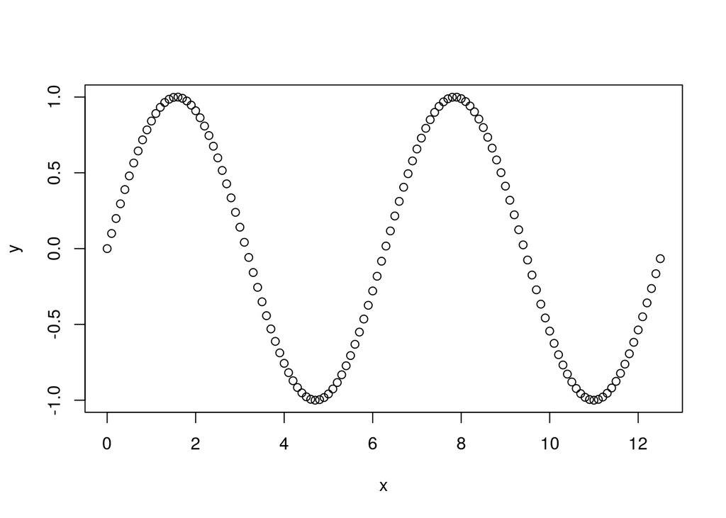

```r
x = seq(0, 4*pi, by=.1)
y = sin(x)
plot(x, y)
```

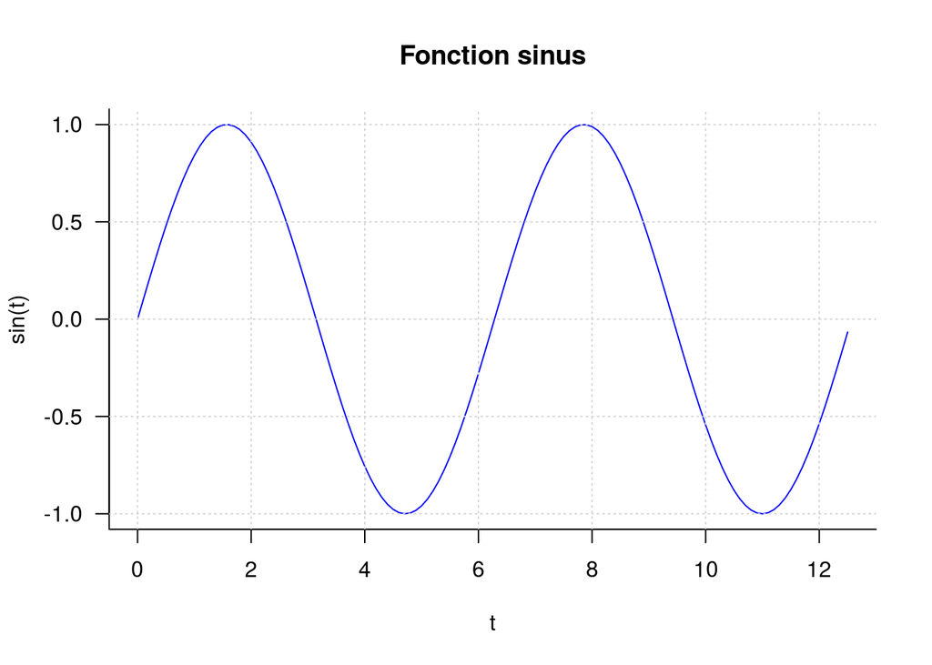

```r
plot(x, y, type='l', col='blue', bty='l', xlab='t', ylab='sin(t)', main='Fonction sinus', las=1)
grid()
```

On peut afficher des données:

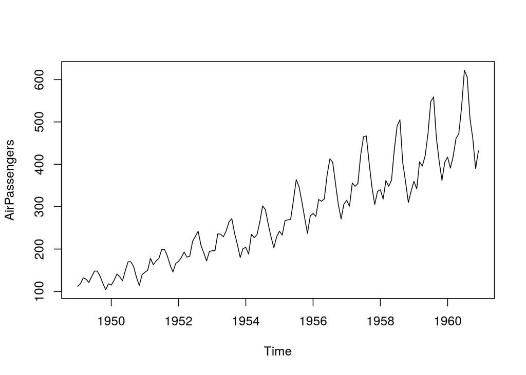

```r
data("AirPassengers")
plot(AirPassengers)
```

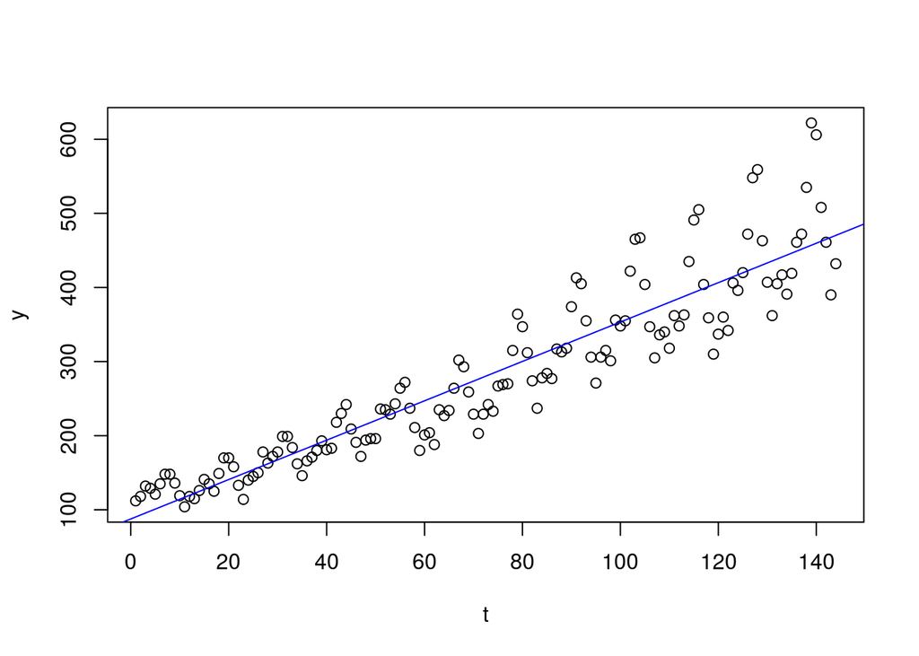

```r
data("AirPassengers")
t = 1:144
y = as.vector(AirPassengers)
plot(t, y)
abline(lm(y ~ t), col='blue')
```

Afficher plusieurs fonctions:

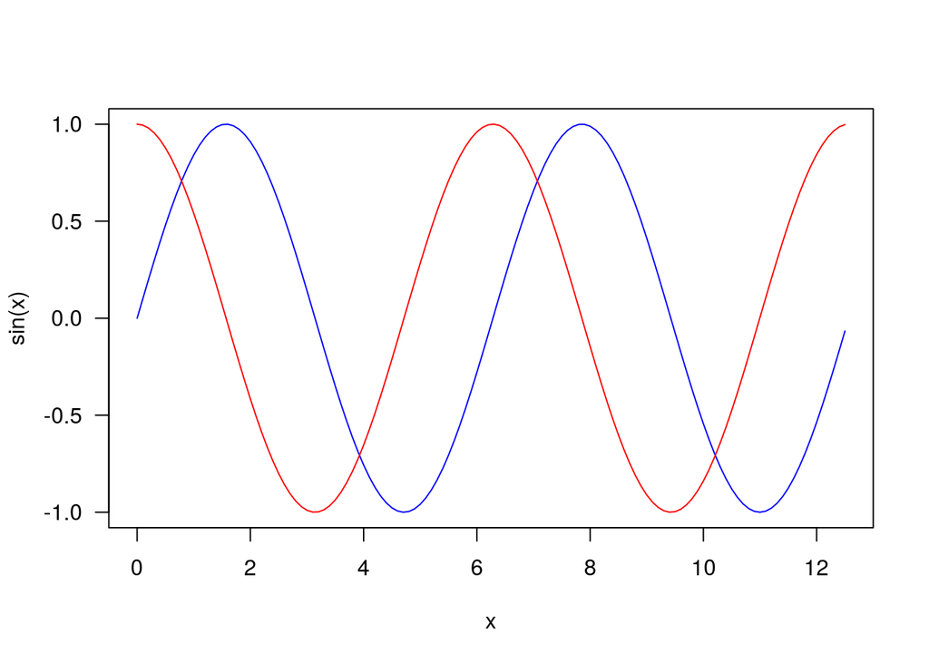

```r
plot(x, sin(x), col='blue', type='l', las=1)
lines(x, cos(x), col='red')
```

Pour afficher plusieurs graphiques sur la même page, on utilise le parametre mfrow.

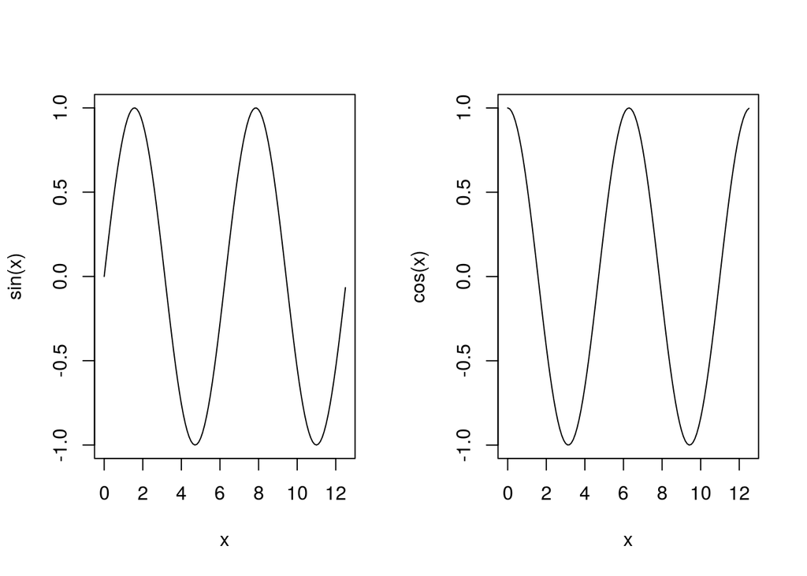

```r
opar = par(no.readonly = T) # sauve les parametres graphiques
par(mfrow=c(1, 2)) # 1 ligne, 2 colonnes
plot(x, sin(x), type='l')
plot(x, cos(x), type='l')
```

```r
par(opar) # restaure les anciens parametres graphiques
```

Afficher les vecteurs colonnes d’une matrice sur des courbes différentes:

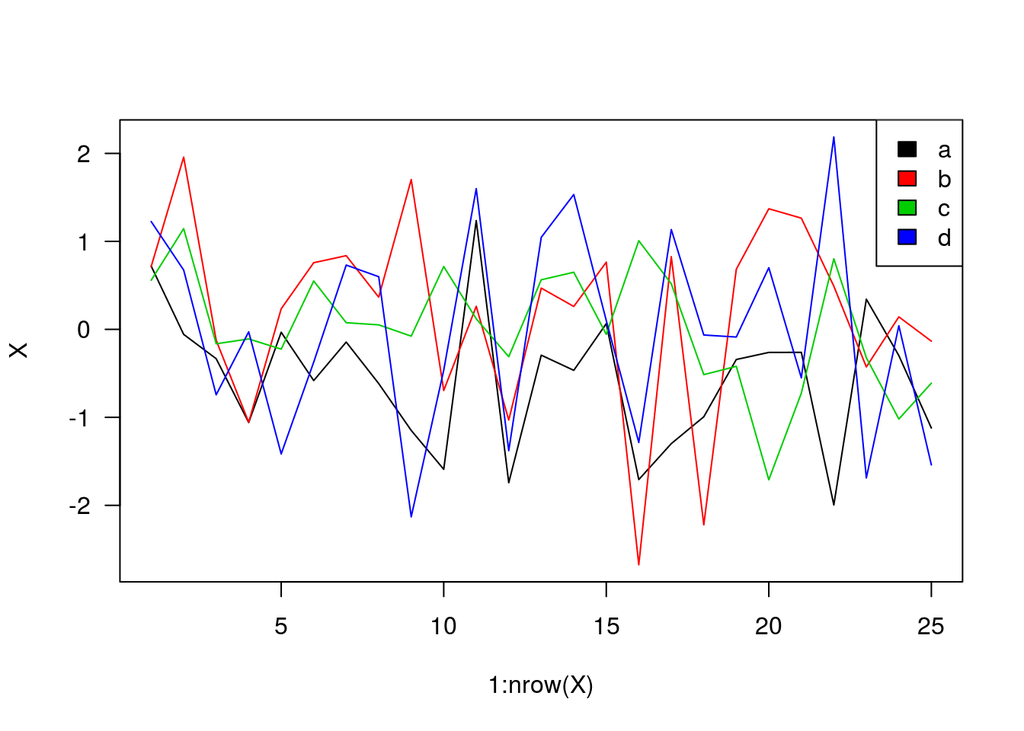

```r
X = matrix(rnorm(100), 25, 4)
matplot(1:nrow(X), X, type='l', lty=1, las=1)
legend("topright", legend=c('a','b','c','d'), fill=1:4)
```

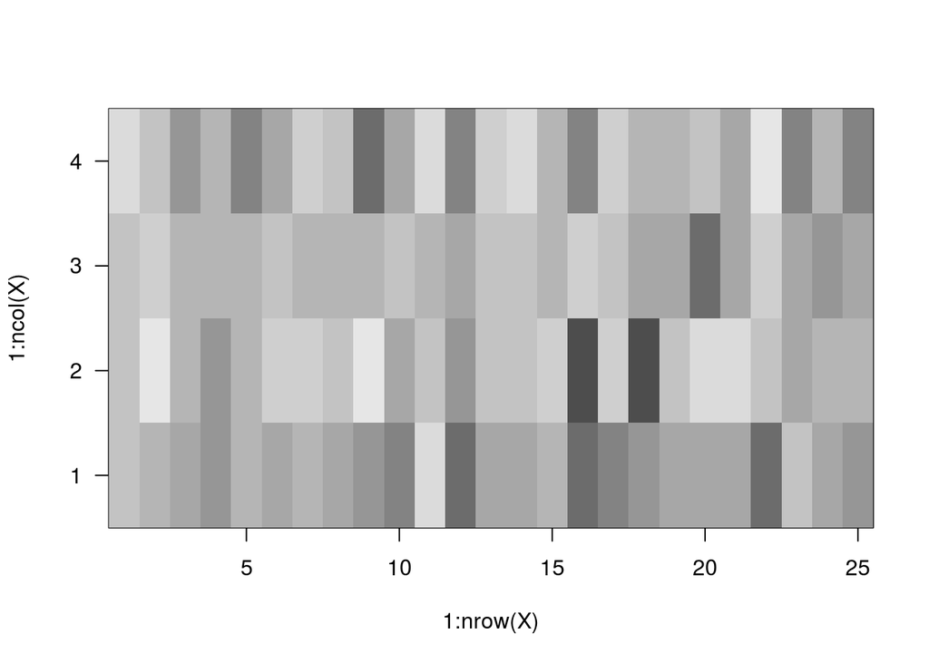

```r
image(x=1:nrow(X), y=1:ncol(X), X, col=gray.colors(10), las=1)
```

Exercice: afficher les données AirPassengers avec chaque année sur une courbe séparée.

#### Afficher les relations 2 à 2 entre des variables :

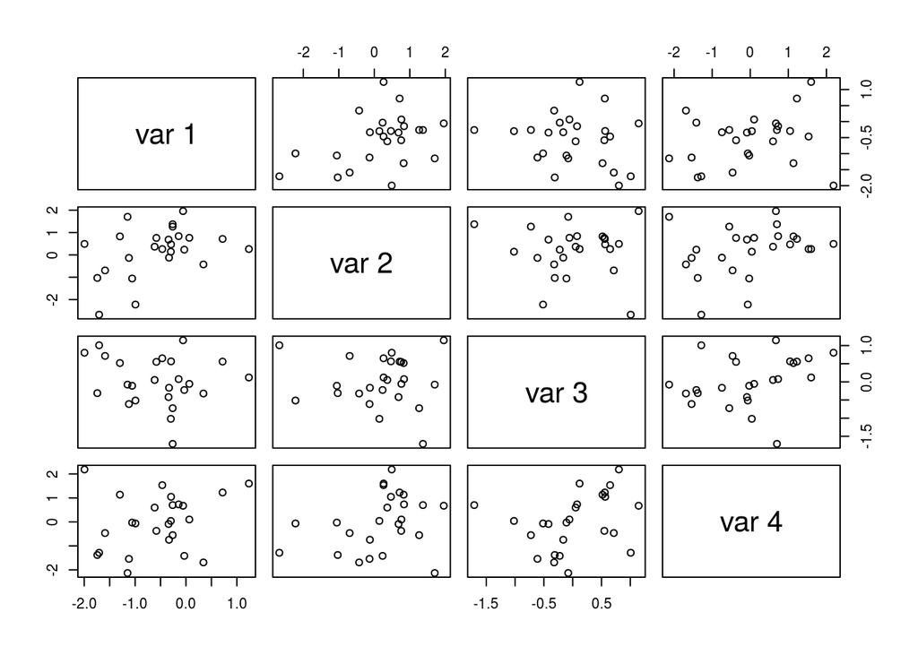

```r
pairs(X)
```

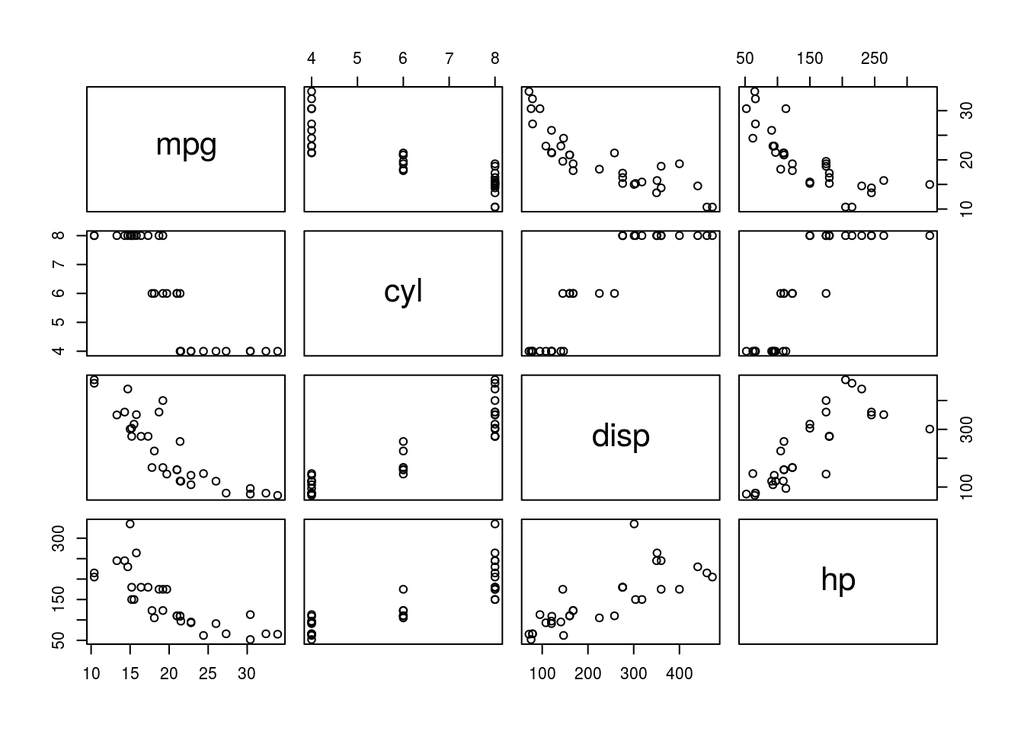

```r
data(mtcars)
pairs(subset(mtcars, select=c('mpg','cyl','disp','hp')))
```

Entre des variables catégorielles:

```r
data("HairEyeColor")
(HairEyeColor)
```

```
## , , Sex = Male
##
##        Eye
## Hair    Brown Blue Hazel Green
##   Black    32   11    10     3
##   Brown    53   50    25    15
##   Red      10   10     7     7
##   Blond     3   30     5     8
##
## , , Sex = Female
##
##        Eye
## Hair    Brown Blue Hazel Green
##   Black    36    9     5     2
##   Brown    66   34    29    14
##   Red      16    7     7     7
##   Blond     4   64     5     8
```

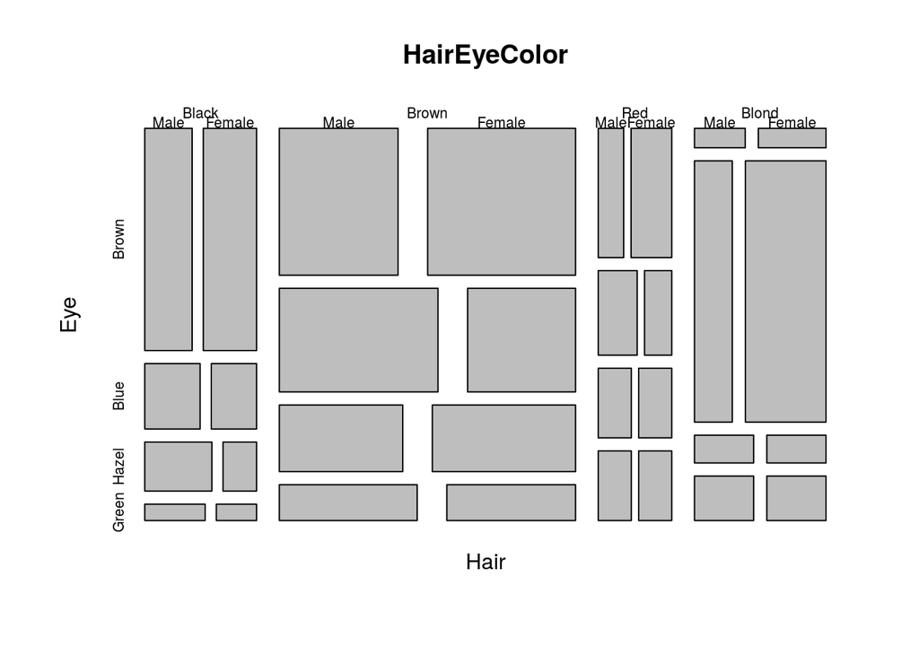

```r
mosaicplot(HairEyeColor)
```

Exercice: Faire deux graphiques distincts pour les hommes et pour les femmes.

### Afficher des distributions:

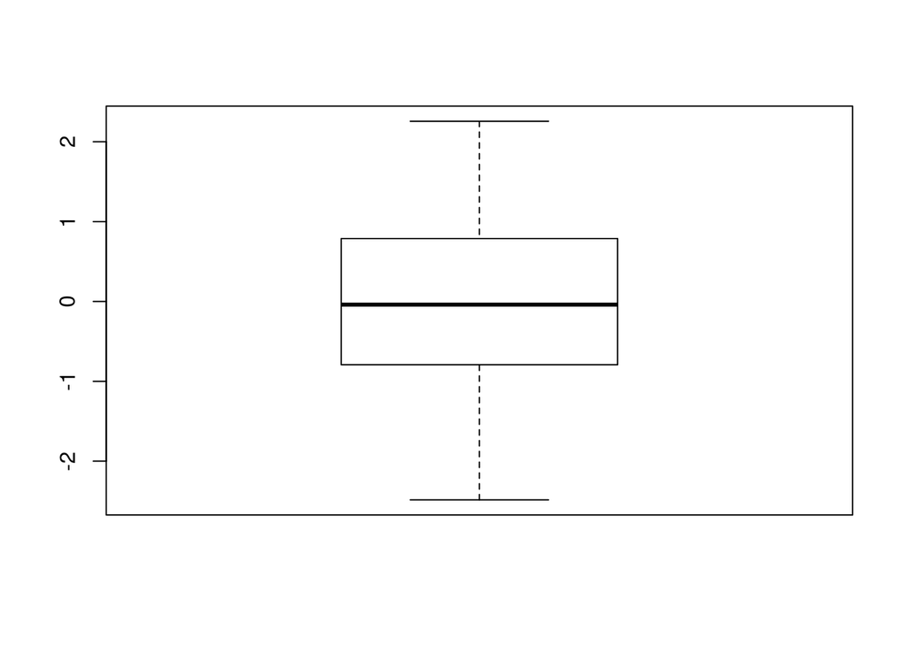

```r
x = rnorm(100)
boxplot(x)
```

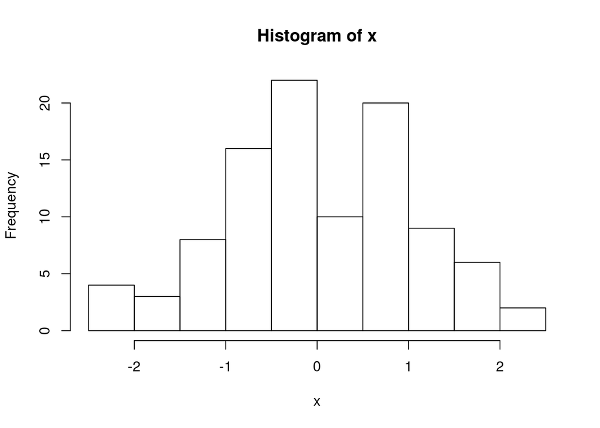

```r
hist(x)
```

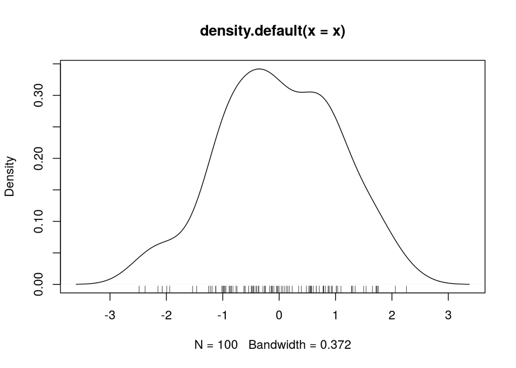

```r
plot(density(x))
rug(x)
```

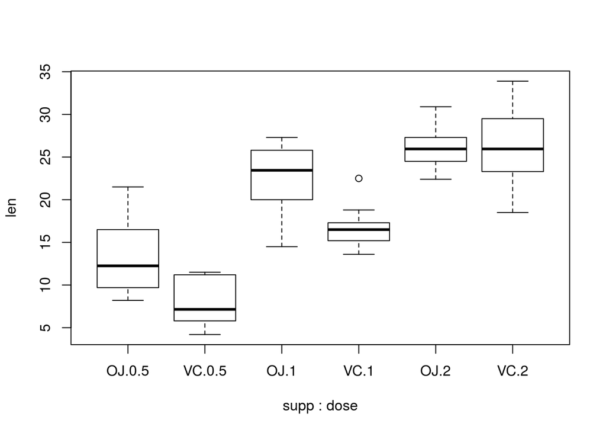

```r
boxplot(len ~ supp + dose, data=ToothGrowth)
```

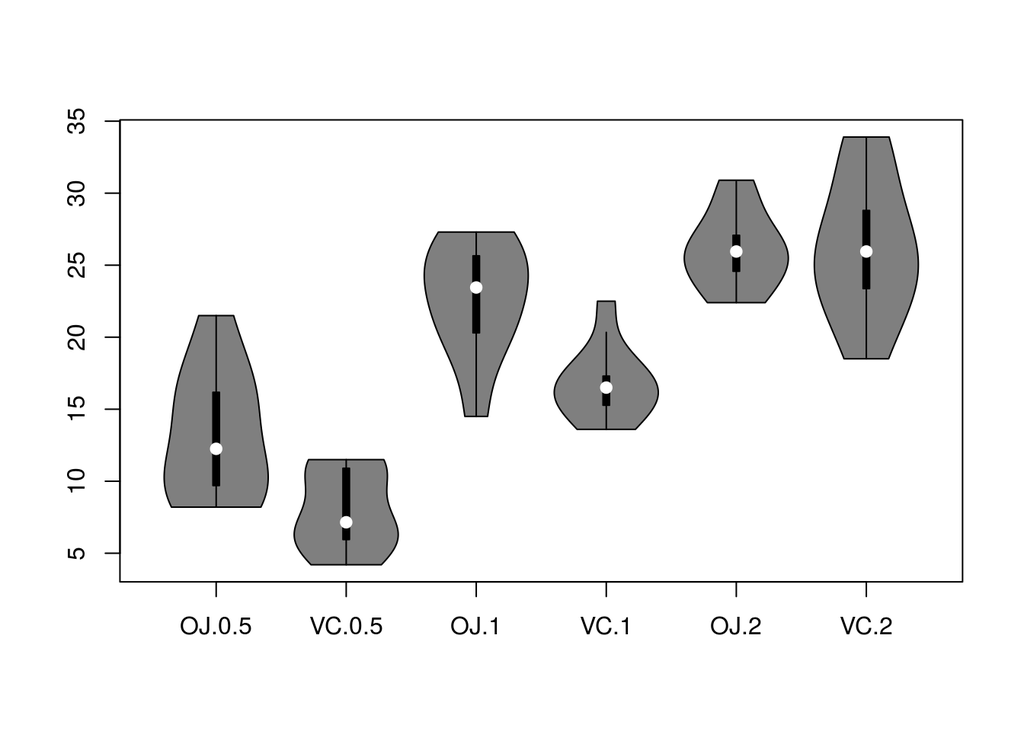

```r
library(vioplot)
vioplot(len ~ supp + dose, data=ToothGrowth)
```

### dotplots

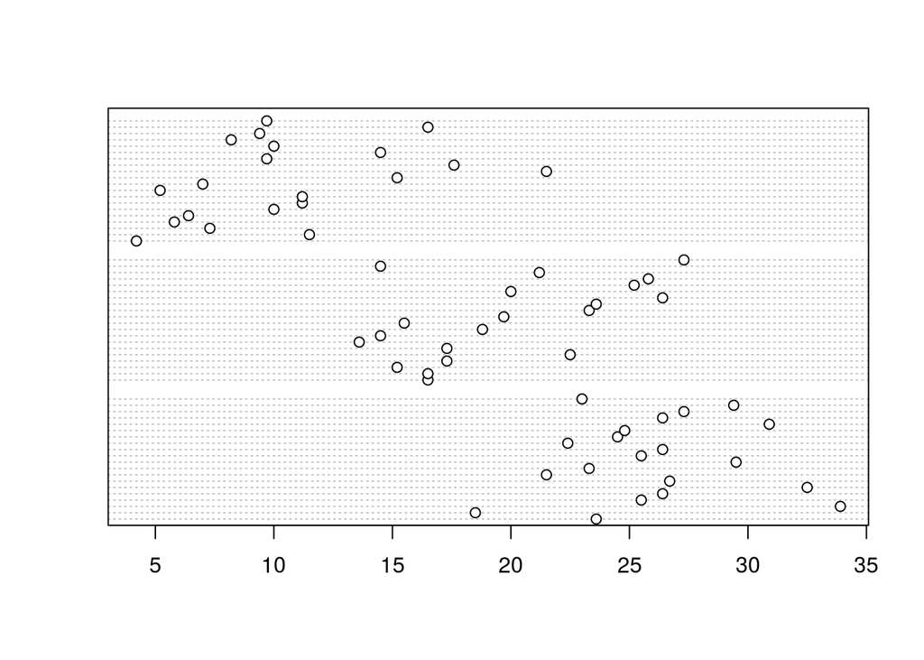

```r
with(ToothGrowth,
     dotchart(len, group=dose))
```

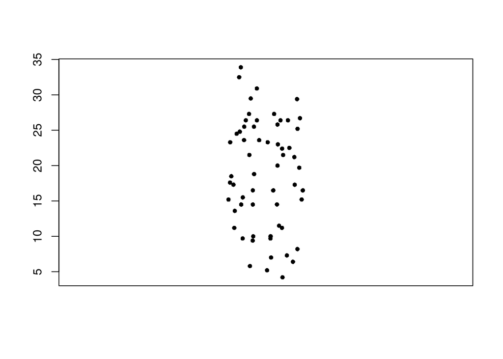

```r
with(ToothGrowth,
     stripchart(len, method='jitter', vertical=T, pch=16, cex=.8)
)
```

#### Diagrammes en bâtons

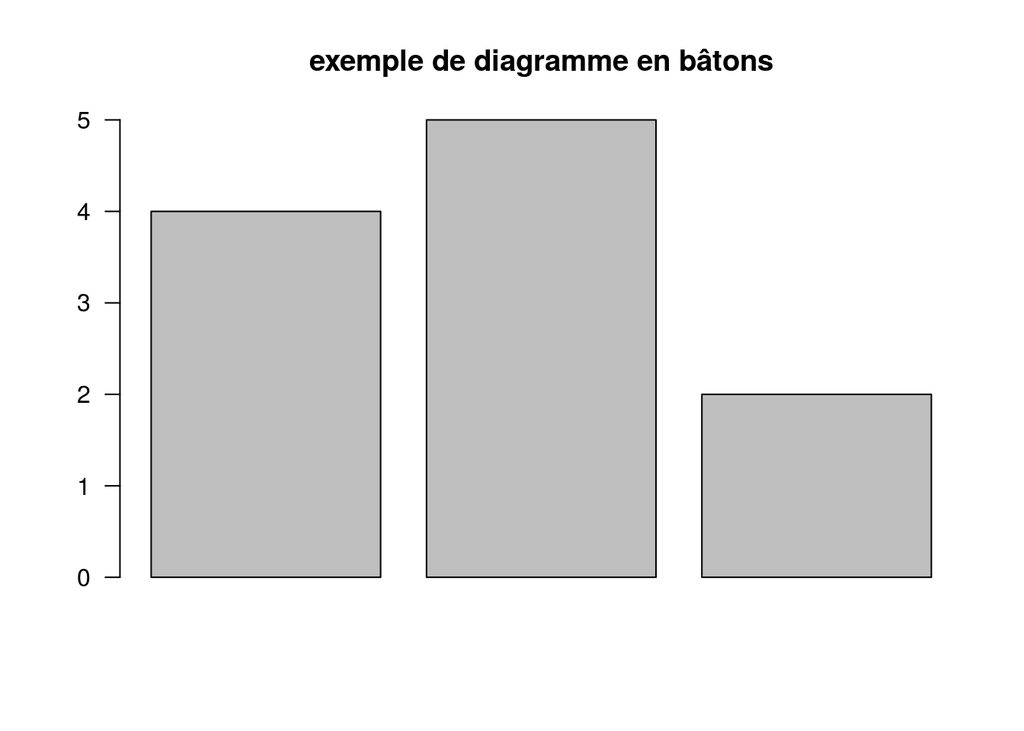

```r
barplot(c(4, 5, 2), las=1, main='exemple de diagramme en bâtons')
```

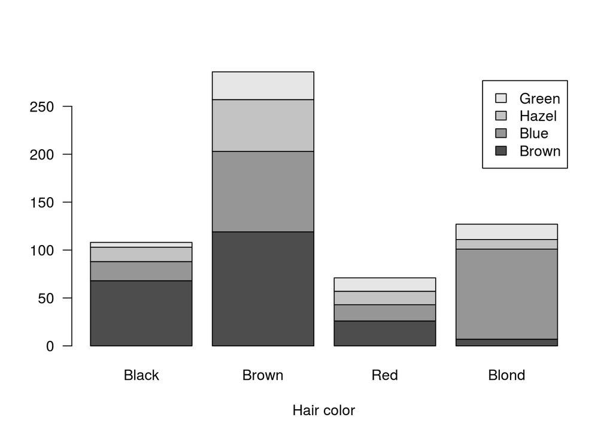

```r
hec = data.frame(HairEyeColor)
barplot(xtabs(Freq ~ Eye + Hair, data=hec), xlab= 'Hair color', legend=T, las=1)
```

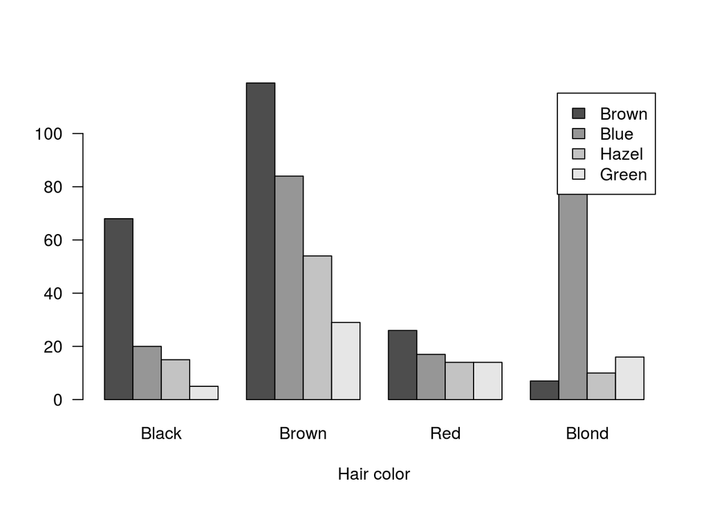

```r
barplot(xtabs(Freq ~ Eye + Hair, data=hec), xlab= 'Hair color', legend=T, las=1, beside=T)
```

Ajouter des barres d’erreurs.

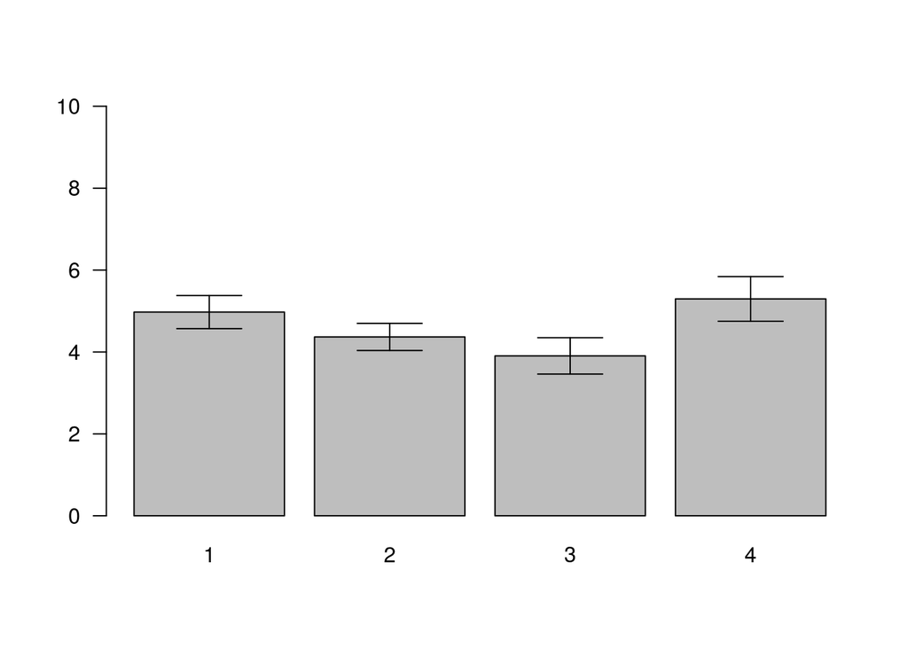

```r
x = rnorm(100, mean=5, sd=2)
categ = gl(4, 25)
means = tapply(x, categ, mean)
mp = barplot(means, ylim=c(0, 10), las=1)
se = tapply(x, categ, function (x) { sd(x)/sqrt(length(x)) })
arrows(mp, means - se, mp, means + se, code=3, angle=90)
```

#### sauvegarder les graphiques dans des fichiers images:

```r
png('sinus.png')
plot(x, sin(x))
graphics.off()
```

```r
pdf('sinus.pdf')
plot(x, sin(x))
graphics.off()
```

Le format `svg` est intéressant si l’on veut retoucher le résultat avec uin logiciel comme inkscape.

```r
svg('sinus.svg')
plot(x, sin(x))
graphics.off()
```

## treillis (lattice)

- *Lattice: Multivariate Data Visualization with R*: https://www.springer.com/gp/book/9780387759685

From https://www.statmethods.net/advgraphs/trellis.html:

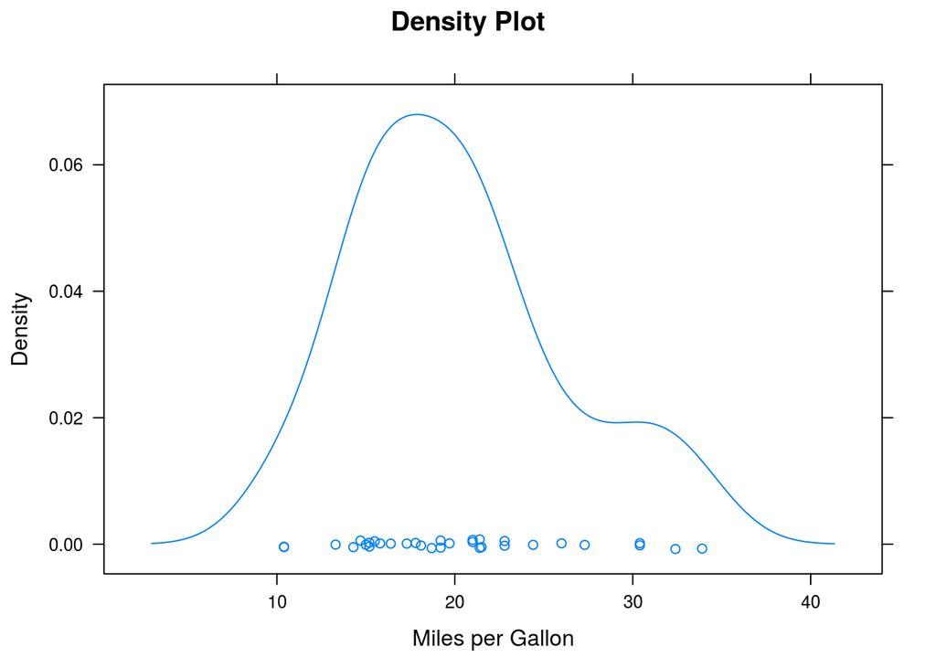

```r
library(lattice)
data("mtcars")
attach(mtcars)


# create factors with value labels
gear.f <- factor(gear, levels=c(3, 4, 5),
                 labels=c("3gears","4gears","5gears"))
cyl.f <- factor(cyl,levels=c(4, 6, 8),
                labels=c("4cyl","6cyl","8cyl"))

# kernel density plot
densityplot(~ mpg,
            main="Density Plot",
            xlab="Miles per Gallon")
```

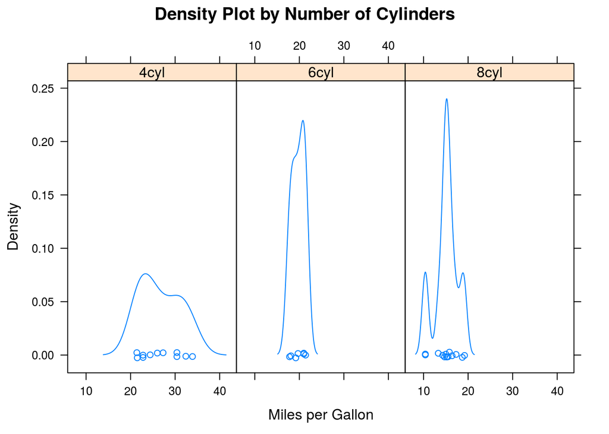

```r
# kernel density plots by factor level
densityplot(~ mpg | cyl.f,
            main="Density Plot by Number of Cylinders",
            xlab="Miles per Gallon")
```

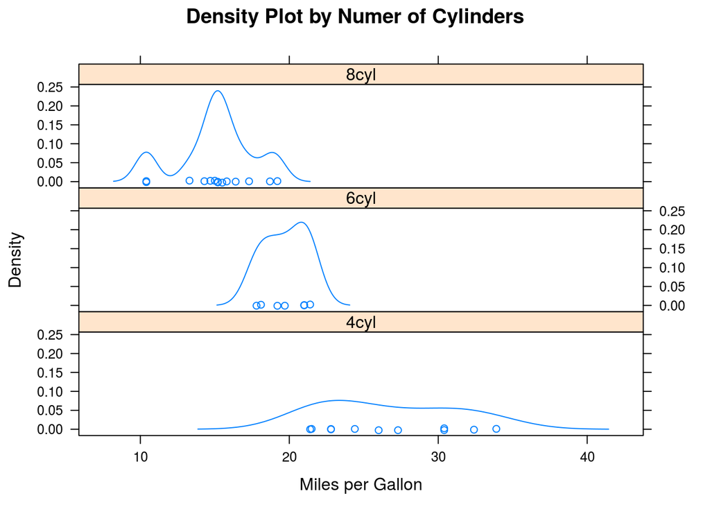

```r
# kernel density plots by factor level (alternate layout)
densityplot(~ mpg | cyl.f,
            main="Density Plot by Numer of Cylinders",
            xlab="Miles per Gallon",
            layout=c(1,3))
```

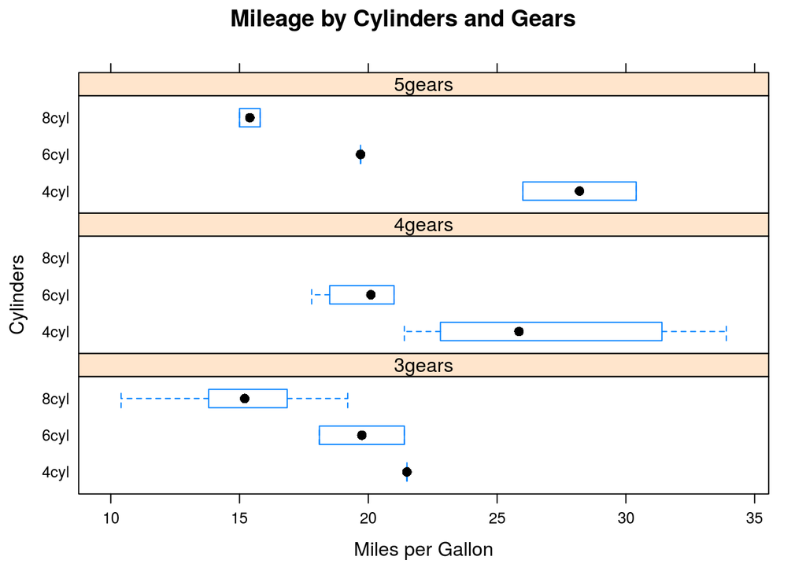

```r
# boxplots for each combination of two factors
bwplot(cyl.f ~ mpg | gear.f,
       ylab="Cylinders", xlab="Miles per Gallon",
       main="Mileage by Cylinders and Gears",
       layout=(c(1,3)))
```